# Ae. aegypti SNP chip: mapping probe sequences to AeagL5 genome assembly

Luciano V. Cosme

2023-12-18

# Analysis code

In this RMarkdown we will overview the probe sequences, generate sequences for mapping with BWA, test our code, and parse the output of the mapping.

## R libraries

```r
library(tidyverse)
library(colorout)
library(here)
library(ggplot2)
library(Biostrings)
library(scales)
library(reticulate)
library(flextable)
library(officer)
library(rmdformats)
library(extrafont)
library(forcats)
library(ggrepel)
library(data.table)
```

## 1. Import the probe sequences

Clear our environment and memory

```r
# clear global environment
rm(list = ls())
# clear memory using garbage collection
gc()
```

```
##           used  (Mb) gc trigger  (Mb) limit (Mb) max used  (Mb)
## Ncells 4371059 233.5    8152108 435.4         NA  7077760 378.0
## Vcells 7440980  56.8   12306261  93.9      32768 10188541  77.8
```

Import probe for the first genome assembly

```r
probes_aegypti_01 <-
  read_delim(
    here(
      "data", "Axiom_aegypti1_Annotation.r2.csv"
    ),
    delim = ",",
    col_names = TRUE,
    show_col_types = FALSE
  )

# check it out
head(probes_aegypti_01)
```

```
## # A tibble: 6 × 26
##   Name        `Affy SNP ID` `dbSNP RS ID` Chromosome `Physical Position` Strand
##   <chr>       <chr>         <chr>         <chr>                    <dbl> <chr>
## 1 AX-93213911 Affx-91582735 ---           SC1.18                  165623 +
## 2 AX-93213912 Affx-91588383 ---           SC1.57                  520617 +
## 3 AX-93213914 Affx-91579274 ---           SC1.1                   344873 +
## 4 AX-93213915 Affx-91579275 ---           SC1.1                   380803 +
## 5 AX-93213916 Affx-91579276 ---           SC1.1                   393002 +
## 6 AX-93213917 Affx-91579277 ---           SC1.1                   401007 +
## # ℹ 20 more variables: `ChrX pseudo-autosomal region 1` <chr>, Cytoband <chr>,
## #   Sequence <chr>, `Allele A` <chr>, `Allele B` <chr>,
## #   `Associated Gene` <chr>, `Genetic Map...13` <chr>, Microsatellite <chr>,
## #   `Allele Frequencies` <chr>, `Heterozygous Allele Frequencies` <chr>,
## #   `Number of individuals` <chr>, `In Hapmap` <chr>,
## #   `Strand Versus dbSNP` <chr>, `Probe Count` <chr>,
## #   `ChrX pseudo-autosomal region 2` <chr>, `Minor Allele` <chr>, …
```

We can check how many probes are in the foward or reverse strand

```r
unique(probes_aegypti_01$Strand)
```

```
## [1] "+"
```

All the probes are in 5’ to 3’ direction.

Supplemental table 2 from https://doi.org/10.1534/g3.114.016196

```r
probes_aegypti_02 <-
  read_delim(
    here(
      "data", "aegypti.csv"
    ),
    delim = ",",
    col_names = TRUE,
    show_col_types = FALSE
  )

# check it out
head(probes_aegypti_02)
```

```
## # A tibble: 6 × 7
##   Name      `Affy SNP ID` Supercontig Physical Position (z…¹ Sequence `Allele A`
##   <chr>     <chr>         <chr>                        <dbl> <chr>    <chr>
## 1 AX-93213… Affx-91582735 supercont1…                 165623 TTTTAAT… A
## 2 AX-93213… Affx-91588383 supercont1…                 520617 GTCGTCG… A
## 3 AX-93213… Affx-91579274 supercont1…                 344873 CCTTGCT… A
## 4 AX-93213… Affx-91579275 supercont1…                 380803 CTTGAAG… T
## 5 AX-93213… Affx-91579276 supercont1…                 393002 TGCAGAA… A
## 6 AX-93213… Affx-91579277 supercont1…                 401007 TACAGTG… A
## # ℹ abbreviated name: ¹`Physical Position (zero-based)`
## # ℹ 1 more variable: `Allele B` <chr>
```

### 1.1 Generate sequences

Generate the sequences

```r
# create function to get the reverse complement
reverse_complement_vector <- function(dna_seqs) {
  DNAStringSet(dna_seqs) |> reverseComplement() |> as.character()
}

# split the sequence into left and right, create sequences and names
aegypti_seq <-
  probes_aegypti_02 |>
  mutate(
    left_seq = gsub("\\[.*", "", Sequence),
    right_seq = gsub(".*\\]", "", Sequence),
    allele_A_F = paste0(left_seq, `Allele A`, right_seq),
    allele_B_F = paste0(left_seq, `Allele B`, right_seq),
    allele_A_R = reverse_complement_vector(allele_A_F),
    allele_B_R = reverse_complement_vector(allele_B_F),
    allele_N_F = paste0(left_seq, "N", right_seq),
    allele_N_R = reverse_complement_vector(allele_N_F),
    fasta_name_F = paste0(">", Name, "_F"),
    fasta_name_R = paste0(">", Name, "_R")
  ) |>
  select(
    Name, Sequence, fasta_name_F, fasta_name_R, allele_A_F, allele_A_R, allele_B_F, allele_B_R, allele_N_F, allele_N_R
  )

# check the output
head(aegypti_seq)
```

```
## # A tibble: 6 × 10
##   Name       Sequence fasta_name_F fasta_name_R allele_A_F allele_A_R allele_B_F
##   <chr>      <chr>    <chr>        <chr>        <chr>      <chr>      <chr>
## 1 AX-932139… TTTTAAT… >AX-9321391… >AX-9321391… TTTTAATAA… CGCCAGTGT… TTTTAATAA…
## 2 AX-932139… GTCGTCG… >AX-9321391… >AX-9321391… GTCGTCGTT… TTACCAACA… GTCGTCGTT…
## 3 AX-932139… CCTTGCT… >AX-9321391… >AX-9321391… CCTTGCTTG… ATTACACGT… CCTTGCTTG…
## 4 AX-932139… CTTGAAG… >AX-9321391… >AX-9321391… CTTGAAGAT… TGGCTATAC… CTTGAAGAT…
## 5 AX-932139… TGCAGAA… >AX-9321391… >AX-9321391… TGCAGAAAT… GTTCCTGCT… TGCAGAAAT…
## 6 AX-932139… TACAGTG… >AX-9321391… >AX-9321391… TACAGTGGC… TAAAGCTGT… TACAGTGGC…
## # ℹ 3 more variables: allele_B_R <chr>, allele_N_F <chr>, allele_N_R <chr>
```

Creating sequences for each allele with the allele name

```r
aegypti_seq <-
  probes_aegypti_02 |>
  mutate(
    left_seq = gsub("\\[.*", "", Sequence),
    right_seq = gsub(".*\\]", "", Sequence),
    allele_A_F = paste0(left_seq, `Allele A`, right_seq),
    allele_B_F = paste0(left_seq, `Allele B`, right_seq),
    allele_A_R = reverse_complement_vector(allele_A_F),
    allele_B_R = reverse_complement_vector(allele_B_F),
    allele_N_F = paste0(left_seq, "N", right_seq),
    allele_N_R = reverse_complement_vector(allele_N_F),
    fasta_name_AF = paste0(">", Name, "_A_F"),
    fasta_name_AR = paste0(">", Name, "_A_R"),
    fasta_name_BF = paste0(">", Name, "_B_F"),
    fasta_name_BR = paste0(">", Name, "_B_R"),
    fasta_name_NF = paste0(">", Name, "_N_F"),
    fasta_name_NR = paste0(">", Name, "_N_R")
  ) |>
  select(
    Name, Sequence, fasta_name_AF, fasta_name_AR, fasta_name_BF, fasta_name_BR, fasta_name_NF, fasta_name_NR,  allele_A_F, allele_A_R, allele_B_F, allele_B_R, allele_N_F, allele_N_R
  )
```

Create sequences

```r
# For Allele A Forward
aegypti_allele_A_F <-
  aegypti_seq |>
  pivot_longer(cols = c(fasta_name_AF, allele_A_F), names_to = "fasta_name") |>
  arrange(row_number(), fasta_name) |>  # sort by row number and column
  pull(value)

writeLines(
  aegypti_allele_A_F, here(
    "output", "probes", "sequences", "aegypti_A_F.fasta"
  )
)

# For Allele A Reverse
aegypti_allele_A_R <-
  aegypti_seq |>
  pivot_longer(cols = c(fasta_name_AR, allele_A_R), names_to = "fasta_name") |>
  arrange(row_number(), fasta_name) |>  # sort by row number and column
  pull(value)

writeLines(
  aegypti_allele_A_R, here(
    "output", "probes", "sequences", "aegypti_A_R.fasta"
  )
)

# For Allele B Forward
aegypti_allele_B_F <-
  aegypti_seq |>
  pivot_longer(cols = c(fasta_name_BF, allele_B_F), names_to = "fasta_name") |>
  arrange(row_number(), fasta_name) |>  # sort by row number and column
  pull(value)

writeLines(
  aegypti_allele_B_F, here(
    "output", "probes", "sequences", "aegypti_B_F.fasta"
  )
)

# For Allele B Reverse
aegypti_allele_B_R <-
  aegypti_seq |>
  pivot_longer(cols = c(fasta_name_BR, allele_B_R), names_to = "fasta_name") |>
  arrange(row_number(), fasta_name) |>  # sort by row number and column
  pull(value)

writeLines(
  aegypti_allele_B_R, here(
    "output", "probes", "sequences", "aegypti_B_R.fasta"
  )
)

# For Allele N Forward
aegypti_allele_N_F <-
  aegypti_seq |>
  pivot_longer(cols = c(fasta_name_NF, allele_N_F), names_to = "fasta_name") |>
  arrange(row_number(), fasta_name) |>  # sort by row number and column
  pull(value)

writeLines(
  aegypti_allele_B_F, here(
    "output", "probes", "sequences", "aegypti_N_F.fasta"
  )
)

# For Allele N Reverse
aegypti_allele_N_R <-
  aegypti_seq |>
  pivot_longer(cols = c(fasta_name_NR, allele_N_R), names_to = "fasta_name") |>
  arrange(row_number(), fasta_name) |>  # sort by row number and column
  pull(value)

writeLines(
  aegypti_allele_N_R, here(
    "output", "probes", "sequences", "aegypti_N_R.fasta"
  )
)
```

```python
files = [
    "output/probes/sequences/aegypti_A_F.fasta",
    "output/probes/sequences/aegypti_A_R.fasta",
    "output/probes/sequences/aegypti_B_F.fasta",
    "output/probes/sequences/aegypti_B_R.fasta",
]

with open("output/probes/sequences/aegypti_combined.fasta", "w") as out:
    for file_path in files:
        with open(file_path) as file:
            out.writelines(file.readlines())
```

Sanity check SNP Sequence Allele A Allele B AX-93213911 TTTTAATAAGGCAGTGAAACAGCGCTGCGTATACT[A/G]AAGAAGACGGACTGTGCAACTCCACAACACTGGCG A G allele_A_F TTTTAATAAGGCAGTGAAACAGCGCTGCGTATACT[A]AAGAAGACGGACTGTGCAACTCCACAACACTGGCG allele_A_R CGCCAGTGTTGTGGAGTTGCACAGTCCGTCTTCTT[T]AGTATACGCAGCGCTGTTTCACTGCCTTATTAAAA allele_B_F TTTTAATAAGGCAGTGAAACAGCGCTGCGTATACT[G]AAGAAGACGGACTGTGCAACTCCACAACACTGGCG allele_B_R CGCCAGTGTTGTGGAGTTGCACAGTCCGTCTTCTT[C]AGTATACGCAGCGCTGTTTCACTGCCTTATTAAAA allele_N_F TTTTAATAAGGCAGTGAAACAGCGCTGCGTATACT[N]AAGAAGACGGACTGTGCAACTCCACAACACTGGCG allele_N_R CGCCAGTGTTGTGGAGTTGCACAGTCCGTCTTCTT[N]AGTATACGCAGCGCTGTTTCACTGCCTTATTAAAA

Everything looks correct. We can save the sequences.

Check the colnames of aegypti_seq

```r
colnames(aegypti_seq)
```

```
##  [1] "Name"          "Sequence"      "fasta_name_AF" "fasta_name_AR"
##  [5] "fasta_name_BF" "fasta_name_BR" "fasta_name_NF" "fasta_name_NR"
##  [9] "allele_A_F"    "allele_A_R"    "allele_B_F"    "allele_B_R"
## [13] "allele_N_F"    "allele_N_R"
```

Check the saved file

```bash
head output/probes/sequences/aegypti_A_F.fasta
```

```
## >AX-93213911_A_F
## TTTTAATAAGGCAGTGAAACAGCGCTGCGTATACTAAAGAAGACGGACTGTGCAACTCCACAACACTGGCG
## >AX-93213912_A_F
## GTCGTCGTTGGTCGGTGTGATTTCTCAGGTCGATAAATGGCACAAAAAATGTCCCCATAGCTTGTTGGTAA
## >AX-93213914_A_F
## CCTTGCTTGTATTCCTGTCATCGTCCACGTTGCGAAAAACCTTCGCTTTACTAATTTTGTTTACGTGTAAT
## >AX-93213915_A_F
## CTTGAAGATGATCGATGTGGAAGTTATCTTACCGGTGACCATCCATGAGGACAATCAGCCATGTATAGCCA
## >AX-93213916_A_F
## TGCAGAAATTCCTTCATGAAGATCTCCAAGGATTTATCAAGATGTTTTTTTCTAATATCACTAGCAGGAAC
```

Check the saved file

```bash
head output/probes/sequences/aegypti_A_F.fasta
```

```
## >AX-93213911_A_F
## TTTTAATAAGGCAGTGAAACAGCGCTGCGTATACTAAAGAAGACGGACTGTGCAACTCCACAACACTGGCG
## >AX-93213912_A_F
## GTCGTCGTTGGTCGGTGTGATTTCTCAGGTCGATAAATGGCACAAAAAATGTCCCCATAGCTTGTTGGTAA
## >AX-93213914_A_F
## CCTTGCTTGTATTCCTGTCATCGTCCACGTTGCGAAAAACCTTCGCTTTACTAATTTTGTTTACGTGTAAT
## >AX-93213915_A_F
## CTTGAAGATGATCGATGTGGAAGTTATCTTACCGGTGACCATCCATGAGGACAATCAGCCATGTATAGCCA
## >AX-93213916_A_F
## TGCAGAAATTCCTTCATGAAGATCTCCAAGGATTTATCAAGATGTTTTTTTCTAATATCACTAGCAGGAAC
```

To remove all data from python

```r
# python
py_run_string("import gc; gc.collect()")
```

### 1.2 Transfer files to cluster

Transfer sequences to the cluster

```bash
# transfer genomes
rsync -chavzP --stats /Users/lucianocosme/Library/CloudStorage/Dropbox/popgen/brazil/aegypti/output/probes/sequences lvc26@mccleary.ycrc.yale.edu:/ycga-gpfs/project/caccone/lvc26/probes/aegypti
```

### 1.3 The genome sequences

We can create the directories for the genomes we want to test.

```r
# create output directories
dir_names <- c(
  "genomes"
)

for (dir_name in dir_names) {
  here("output", "probes", dir_name) |>
    dir.create(recursive = TRUE, showWarnings = FALSE)
}
```

We can also map the sequences to the reference genome of Aedes aegypti genomes and most of them will not map uniquely.

#### 1.3.1 AaegL5_ncbi

Available at [HERE](https://www.ncbi.nlm.nih.gov/data-hub/genome/GCF_002204515.2/) https://ftp.ncbi.nlm.nih.gov/genomes/all/GCF/002/204/515/GCF_002204515.2_AaegL5.0/ Molecule name GenBank sequence RefSeq sequence Unlocalized sequences count Chromosome 1 CM008043.1 = NC_035107.1 0 Chromosome 2 CM008044.1 = NC_035108.1 0 Chromosome 3 CM008045.1 = NC_035109.1 0 unplaced n/a n/a n/a 2,306

```bash
# run the code on the terminal
# I will save it on my external SSD

# go to dir
cd /Volumes/evo2/probes_genomes

# download it
curl -v -OJX GET "https://api.ncbi.nlm.nih.gov/datasets/v2alpha/genome/accession/GCF_002204515.2/download?include_annotation_type=GENOME_FASTA,GENOME_GFF,RNA_FASTA,CDS_FASTA,PROT_FASTA,SEQUENCE_REPORT&filename=GCF_002204515.2.zip" -H "Accept: application/zip";

# unzip it
unzip GCF_002204515.2.zip

# rename the unziped data
mv ncbi_dataset AaegL5_ncbi

# check the scaffold names
head -n 1 AaegL5_ncbi/data/GCF_002204515.2/GCF_002204515.2_AaegL5.0_genomic.fna
# >NC_035107.1 Aedes aegypti strain LVP_AGWG chromosome 1, AaegL5.0 Primary Assembly, whole genome shotgun sequence

# get the 3 chromosomes names
grep "chromosome" AaegL5_ncbi/data/GCF_002204515.2/GCF_002204515.2_AaegL5.0_genomic.fna | head
# >NC_035107.1 Aedes aegypti strain LVP_AGWG chromosome 1, AaegL5.0 Primary Assembly, whole genome shotgun sequence
# >NC_035108.1 Aedes aegypti strain LVP_AGWG chromosome 2, AaegL5.0 Primary Assembly, whole genome shotgun sequence
# >NC_035109.1 Aedes aegypti strain LVP_AGWG chromosome 3, AaegL5.0 Primary Assembly, whole genome shotgun sequence
# MT    MF194022.1  NC_035159.1

# rename the remaining scaffolds
awk '/^>NC_035107\.1/{print ">1";next} /^>NC_035108\.1/{print ">2";next} /^>NC_035109\.1/{print ">3";next} /^>NC_035159\.1/{print ">MT";next} 1' AaegL5_ncbi/data/GCF_002204515.2/GCF_002204515.2_AaegL5.0_genomic.fna > AaegL5_ncbi.fasta

# check the output
grep ">" AaegL5_ncbi.fasta | head -n 5
# >1
# >2
# >3
# >NW_018734407.1 Aedes aegypti strain LVP_AGWG unplaced genomic scaffold, AaegL5.0 Primary Assembly AGWG_AaegL5_hic_scaff_1000_PBJ_arrow, whole genome shotgun sequence
# >NW_018734408.1 Aedes aegypti strain LVP_AGWG unplaced genomic scaffold, AaegL5.0 Primary Assembly AGWG_AaegL5_hic_scaff_1001_PBJ_arrow, whole genome shotgun sequence

# rename the other scaffolds
sed 's/^>\([^[:space:]]*\)\.1.*/>\1/' AaegL5_ncbi.fasta > AaegL5_ncbi.fasta.tmp && mv AaegL5_ncbi.fasta.tmp AaegL5_ncbi.fasta

# check it
 grep ">"  AaegL5_ncbi.fasta | head -n 5
# >1
# >2
# >3
# >NW_018734407
# >NW_018734408

# now the reference genome is ready for indexing. I will do it later on the cluster
```

Assembly statistics

RefSeq GenBank Genome size 1.3 Gb 1.3 Gb Total ungapped length 1.3 Gb 1.3 Gb Number of chromosomes 3 3 Number of organelles 1 1 Number of scaffolds 2,309 2,309 Scaffold N50 409.8 Mb 409.8 Mb Scaffold L50 2 2 Number of contigs 2,538 2,538 Contig N50 11.8 Mb 11.8 Mb Contig L50 30 30 GC percent 38 38 Genome coverage 110.0x 110.0x Assembly level Chromosome Chromosome Note: there are 2306 unplaced scaffolds in this assembly Chromosomes and MT scaffolds: GenBank RefSeq 1 CM008043.1 NC_035107.1 2 CM008044.1 NC_035108.1 3 CM008045.1 NC_035109.1 MT MF194022.1 NC_035159.1

#### 1.3.2 AaegL5_vb

The genome from Vector Base

Available at [HERE](https://vectorbase.org/common/downloads/release-62/AaegyptiLVP_AGWG/fasta/data/VectorBase-62_AaegyptiLVP_AGWG_Genome.fasta)

```bash
# run the code on the terminal
# I will save it on my external SSD

# go to dir
cd /Volumes/evo2/probes_genomes

# download it
wget https://vectorbase.org/common/downloads/release-62/AaegyptiLVP_AGWG/fasta/data/VectorBase-62_AaegyptiLVP_AGWG_Genome.fasta

# check the scaffold names
grep ">" VectorBase-62_AaegyptiLVP_AGWG_Genome.fasta | head -n 5
# >AaegL5_1 | organism=Aedes_aegypti_LVP_AGWG | version=AaegL5 | length=310827022 | SO=chromosome
# >AaegL5_2 | organism=Aedes_aegypti_LVP_AGWG | version=AaegL5 | length=474425716 | SO=chromosome
# >AaegL5_3 | organism=Aedes_aegypti_LVP_AGWG | version=AaegL5 | length=409777670 | SO=chromosome
# >AaegL5_MT | organism=Aedes_aegypti_LVP_AGWG | version=AaegL5 | length=16790 | SO=mitochondrial_chromosome
# >NIGP01000004 | organism=Aedes_aegypti_LVP_AGWG | version=AaegL5 | length=30735 | SO=supercontig

# rename the remaining scaffolds
awk '/^>AaegL5_1/{print ">1"} /^>AaegL5_2/{print ">2"} /^>AaegL5_3/{print ">3"} /^>AaegL5_MT/{print ">MT"} !/^>AaegL5_1|^>AaegL5_2|^>AaegL5_3|^>AaegL5_MT/{print}' VectorBase-62_AaegyptiLVP_AGWG_Genome.fasta > AaegL5_vb.fasta


# check the output
grep ">" AaegL5_vb.fasta | head -n 5
# >1
# >2
# >3
# >MT
# >NIGP01000004 | organism=Aedes_aegypti_LVP_AGWG | version=AaegL5 | length=30735 | SO=supercontig

# rename the other scaffolds
sed 's/^>\([^[:space:]]*\).*/>\1/' AaegL5_vb.fasta > AaegL5_vb.fasta.tmp && mv AaegL5_vb.fasta.tmp AaegL5_vb.fasta

# check it
cat AaegL5_vb.fasta | grep ">"  | head -n 5
# >1
# >2
# >3
# >MT
# >NIGP01000004

# now the reference genome is ready for indexing. I will do it later on the cluster
```

We can compress and transfer the files to the our project directory

```bash
ls -1 /Volumes/evo2/probes_genomes/*.fasta
```

Compress genomes and put in project directory

```bash
for file in /Volumes/evo2/probes_genomes/*.fasta; do bgzip --threads 6 "$file" -c > /Users/lucianocosme/Library/CloudStorage/Dropbox/popgen/brazil/aegypti/output/probes/genomes/"$(basename "$file").gz"; done
```

## 3. Mapping sequences on the HPC

### 3.1 Transfer files to cluster

Genomes

```bash
# transfer genomes
rsync -chavzP --stats /Users/lucianocosme/Library/CloudStorage/Dropbox/popgen/brazil/aegypti/output/probes/genomes lvc26@mccleary.ycrc.yale.edu:/ycga-gpfs/project/caccone/lvc26/probes/aegypti
```

Decompress genomes

```bash
# create interactive session with 1 CPU
salloc --partition devel --time=06:00:00 --nodes=1 --ntasks=1 --cpus-per-task=1 --mem-per-cpu=10Gb zsh

# decompress
for file in genomes/*.gz; do gzip -d "$file"; done
```

Index with Samtools

```bash
# load samtools
module load SAMtools/1.16-GCCcore-10.2.0

# index the genomes
for file in /ycga-gpfs/project/caccone/lvc26/probes/genomes/*.fasta
do
    samtools faidx "$file"
done
```

Probe sequences

```bash
# next we can download the files to our computer, run the command below in your computer, not in the cluster.
rsync -chavzP --stats /Users/lucianocosme/Library/CloudStorage/Dropbox/popgen/brazil/aegypti/output/probes/sequences lvc26@mccleary.ycrc.yale.edu:/ycga-gpfs/project/caccone/lvc26/probes/aegypti
```

### 3.2 Index the reference genomes

If you want to get BWA on the cluster or your computer

```bash
# go to dir
cd /ycga-gpfs/project/caccone/lvc26/probes

# download
wget https://github.com/lh3/bwa/releases/download/v0.7.17/bwa-0.7.17.tar.bz2

# decompress
tar -xjf bwa-0.7.17.tar.bz2

# go to dir
cd bwa-0.7.17

# compile
make

# to use it on the scripts
export PATH=/ycga-gpfs/project/caccone/lvc26/probes/bwa-0.7.17:$PATH
```

Get bowtie2

```bash
# download it
wget https://github.com/BenLangmead/bowtie2/releases/download/v2.4.4/bowtie2-2.4.4-linux-x86_64.zip

# unzip
unzip bowtie2-2.4.4-linux-x86_64.zip

# export path on the batch scripts
export PATH=/ycga-gpfs/project/caccone/lvc26/probes/bowtie2-2.4.4-linux-x86_64:$PATH
```

Get Samtools

Dependency: install libncurses5-dev

```bash
# download
wget https://invisible-mirror.net/archives/ncurses/ncurses-6.3.tar.gz

# extract
tar -xzf ncurses-6.3.tar.gz

# move to dir
cd ncurses-6.3

# configure
./configure --prefix=/gpfs/ycga/project/caccone/lvc26/probes/ncurses-6.3

# compile
make

# install
make install

# export path
export PATH=/gpfs/ycga/project/caccone/lvc26/probes/ncurses-6.3:$PATH

# add the ncurses library directory to your LD_LIBRARY_PATH variable
export LD_LIBRARY_PATH=/gpfs/ycga/project/caccone/lvc26/probes/ncurses-6.3/lib:$LD_LIBRARY_PATH
```

```bash
# download it
wget https://github.com/samtools/samtools/releases/download/1.13/samtools-1.13.tar.bz2

# unzip
tar -xjf samtools-1.13.tar.bz2

# go to dir
cd samtools-1.13


# Check if the libbz2 library is installed
ldconfig -p | grep libbz2

module load GCCcore/12.2.0
# configure it
./configure --prefix=/ycga-gpfs/project/caccone/lvc26/probes/samtools-1.13 --with-bz2=/lib64

# install it
make install

# export path on the batch scripts
export PATH=/ycga-gpfs/project/caccone/lvc26/probes/samtools-1.13:$PATH
```

Create interactive session, load modules, and test them

```bash
# create interactive session with 1 CPU
salloc --partition devel --time=06:00:00 --nodes=1 --ntasks=1 --cpus-per-task=1 --mem-per-cpu=5120 zsh

# or  create interactive session with 4 CPUs
salloc --partition devel --time=06:00:00 --nodes=1 --ntasks=1 --cpus-per-task=4 --mem-per-cpu=5120 zsh

# modules
module load BWA/0.7.17-GCCcore-10.2.0 # I am having problems with it
module load Bowtie2/2.4.2-GCCcore-1
module load SAMtools/1.16-GCCcore-10.2.0

# check if they are working or check their versions. I had issues with them and I decided to install my own versions.
```

Create files to use with Slurm

```bash
# go to dir
cd /ycga-gpfs/project/caccone/lvc26/probes/aegypti/scripts

# create genome files
ls -1 /ycga-gpfs/project/caccone/lvc26/probes/aegypti/genomes/*.fasta > genomes.txt
ls -1 /ycga-gpfs/project/caccone/lvc26/probes/aegypti/genomes/*.fasta | sed 's/.*\/\([^\/]*\)\.fasta/\1/' > genome_names.txt

# create sample files
ls -1 /ycga-gpfs/project/caccone/lvc26/probes/aegypti/sequences/*.fasta > sequences.txt
ls -1 /ycga-gpfs/project/caccone/lvc26/probes/aegypti/sequences/*.fasta | sed 's/.*\/\([^\/]*\)\.fasta/\1/' > sequence_names.txt
```

Index with bwa

```bash
#!/bin/bash
#SBATCH --mail-type=END,FAIL
#SBATCH --mail-user=luciano.cosme@yale.edu
#SBATCH --job-name=bwa
#SBATCH --partition=day
#SBATCH --time=12:00:00
#SBATCH --cpus-per-task=1
#SBATCH --mem-per-cpu=20Gb
#SBATCH --array=1-2
#SBATCH -o /ycga-gpfs/project/caccone/lvc26/probes/aegypti/scripts/bwa_logs/bwa_index_%A_%a.o.txt
#SBATCH -e /ycga-gpfs/project/caccone/lvc26/probes/aegypti/scripts/bwa_logs/bwa_index_%A_%a.ERROR.txt

# load modules (twice the module was not working and I had to contact HPC support)
# module load BWA/0.7.17-GCCcore-10.2.0

# use my own
export PATH=/ycga-gpfs/project/caccone/lvc26/probes/aegypti/bwa-0.7.17:$PATH

# go to dir
cd /ycga-gpfs/project/caccone/lvc26/probes/aegypti/scripts

# Set job name, output, and error environment variables
genomes="/ycga-gpfs/project/caccone/lvc26/probes/aegypti/scripts/genomes.txt"
gnames="/ycga-gpfs/project/caccone/lvc26/probes/aegypti/scripts/genome_names.txt"

threads=$SLURM_CPUS_PER_TASK

genomes_count=$(wc -l < "$genomes")

genome_idx=$((($SLURM_ARRAY_TASK_ID - 1) % $genomes_count + 1))

genome=$(sed -n "${genome_idx}p" "$genomes" | awk '{print $1}')
gname=$(sed -n "${genome_idx}p" "$gnames" | awk '{print $1}')

# sanity checks
echo "SLURM_ARRAY_TASK_ID: $SLURM_ARRAY_TASK_ID"
echo "Genome file: $genome"
echo "Genome name: $gname"

# create index
bwa index $genome;

# create file that maps the task ID to the genome and sequence names
gname=$(sed -n "${genome_idx}p" /ycga-gpfs/project/caccone/lvc26/probes/aegypti/scripts/genome_names.txt | awk '{print $1}')
echo "$SLURM_ARRAY_TASK_ID:$gname" >> /gpfs/ycga/project/caccone/lvc26/probes/aegypti/scripts/bwa_logs/bwa_index_task_id_mapping.txt
```

Update logs

```bash
#!/bin/sh
#SBATCH --mail-type=END,FAIL
#SBATCH --mail-user=luciano.cosme@yale.edu
#SBATCH --partition=day
#SBATCH --ntasks=1
#SBATCH --cpus-per-task=1
#SBATCH --mem-per-cpu=5G
#SBATCH --time=12:00:00
#SBATCH --job-name=bwa_indexL
#SBATCH -o /ycga-gpfs/project/caccone/lvc26/probes/aegypti/scripts/bwa_logs/bwa_index_%A_%a.o.txt
#SBATCH -e /ycga-gpfs/project/caccone/lvc26/probes/aegypti/scripts/bwa_logs/bwa_index_%A_%a.ERROR.txt

# go to dir
cd /gpfs/ycga/project/caccone/lvc26/probes/aegypti/scripts/bwa_logs

# rename the log files
while IFS=: read -r task_id gname; do
  for ext in o.txt ERROR.txt; do
    for old_file in bwa_index_*_${task_id}.${ext}; do
      if [ -e "$old_file" ]; then
        new_file="bwa_index_${gname}.${ext}"
        mv "$old_file" "$new_file"
      fi
    done
  done
done < "bwa_index_task_id_mapping.txt"
```

Job wrapper for bwa index jobs

```bash
#!/bin/sh
#SBATCH --mail-type=END,FAIL
#SBATCH --mail-user=luciano.cosme@yale.edu
#SBATCH --partition=day
#SBATCH --ntasks=1
#SBATCH --cpus-per-task=1
#SBATCH --mem-per-cpu=1G
#SBATCH --time=12:00:00
#SBATCH --job-name=bwa_indexW
#SBATCH -o /ycga-gpfs/project/caccone/lvc26/probes/aegypti/scripts/bwa_logs/bwa_wrapper_%A_%a.o.txt
#SBATCH -e /ycga-gpfs/project/caccone/lvc26/probes/aegypti/scripts/bwa_logs/bwa_wrapper_%A_%a.ERROR.txt

# go to dir
cd /gpfs/ycga/project/caccone/lvc26/probes/aegypti/scripts

# Submit job 1a
job_A_id=$(sbatch 1a.bwa_index.sh | awk '{print $4}')

# Submit job 1b with a dependency on the successful completion of job 1a
job_B_id=$(sbatch --dependency=afterok:${job_A_id} 1b.bwa_index.sh | awk '{print $4}')
```

We can write a function to save the chunks

````r
# Define a custom function to write the content of the chunk with the specified label
write_chunk <- function(rmd_file_path, label, output_directory, script_name) {
  # Read the Rmd file
  rmd_lines <- readLines(rmd_file_path)

  # Find the line numbers of the chunk start and end
  start_line <- grep(paste0("```\\{bash ", label), rmd_lines)
  end_line <- grep("```", rmd_lines[(start_line + 1):length(rmd_lines)]) + start_line

  # Extract the content of the chunk
  chunk_content <- rmd_lines[(start_line + 1):(end_line - 1)]

  # Save the content of the chunk to a file
  file_path <- file.path(output_directory, script_name)
  cat(chunk_content, sep = "\n", file = file_path)
  message("Bash script saved as: ", file_path)
}

# we can save the function to source it later
dump(
  "write_chunk",
  here(
    "scripts", "analysis", "write_chunk.R")
)
````

Now we can save the bash chunks. Save the RMarkdown before run this code below

```r
# Set the R Markdown file path
rmd_file_path <- "scripts/RMarkdown_files/02.mapping_probes.Rmd"

# Set the output directory
output_directory <- "output/probes/scripts"

# Write the content of the chunk with the specified label
write_chunk(rmd_file_path, "1a.bwa_index.sh", output_directory, "1a.bwa_index.sh")
```

```
## Bash script saved as: output/probes/scripts/1a.bwa_index.sh
```

```r
write_chunk(rmd_file_path, "1b.bwa_index.sh", output_directory, "1b.bwa_index.sh")
```

```
## Bash script saved as: output/probes/scripts/1b.bwa_index.sh
```

```r
write_chunk(rmd_file_path, "1.bwa_index.sh", output_directory, "1.bwa_index.sh")
```

```
## Bash script saved as: output/probes/scripts/1.bwa_index.sh
```

## 4. Mapping probe sequences with BWA on the cluster

We will use the HPC cluster to speed up our alignments.

### 4.1 Map with the default parameters (BWA MEM)

Default parameters batch script - NOTE: I run the bwa with different seeds and use the flag -a to report all the alignments. I kept this part to show how I did step by step.

```bash
#!/bin/sh
#SBATCH --mail-type=END,FAIL
#SBATCH --mail-user=luciano.cosme@yale.edu
#SBATCH --partition=day
#SBATCH --ntasks=1
#SBATCH --cpus-per-task=10
#SBATCH --mem-per-cpu=5G
#SBATCH --time=12:00:00
#SBATCH --array=1-18
#SBATCH --job-name=bwa_default
#SBATCH -o /ycga-gpfs/project/caccone/lvc26/probes/aegypti/scripts/bwa_logs/bwa_default_%A_%a.o.txt
#SBATCH -e /ycga-gpfs/project/caccone/lvc26/probes/aegypti/scripts/bwa_logs/bwa_default_%A_%a.ERROR.txt

# load modules
module load BWA/0.7.17-GCCcore-10.2.0
module load SAMtools/1.16-GCCcore-10.2.0

# go to dir
cd /ycga-gpfs/project/caccone/lvc26/probes/aegypti/scripts

# Set job name, output, and error environment variables
genomes="/ycga-gpfs/project/caccone/lvc26/probes/aegypti/scripts/genomes.txt"
gnames="/ycga-gpfs/project/caccone/lvc26/probes/aegypti/scripts/genome_names.txt"
sequences="/ycga-gpfs/project/caccone/lvc26/probes/aegypti/scripts/sequences.txt"
snames="/ycga-gpfs/project/caccone/lvc26/probes/aegypti/scripts/sequence_names.txt"

threads=$SLURM_CPUS_PER_TASK

genomes_count=$(wc -l < "$genomes")
sequences_count=$(wc -l < "$sequences")

genome_idx=$((($SLURM_ARRAY_TASK_ID - 1) % $genomes_count + 1))
sequence_idx=$((($SLURM_ARRAY_TASK_ID - 1) / $genomes_count + 1))

genome=$(sed -n "${genome_idx}p" "$genomes" | awk '{print $1}')
gname=$(sed -n "${genome_idx}p" "$gnames" | awk '{print $1}')
sequence=$(sed -n "${sequence_idx}p" "$sequences" |  awk '{print $1}')
sname=$(sed -n "${sequence_idx}p" "$snames" | awk '{print $1}')

# sanity checks
echo "SLURM_ARRAY_TASK_ID: $SLURM_ARRAY_TASK_ID"
echo "Genome file: $genome"
echo "Genome name: $gname"
echo "Sequence file: $sequence"
echo "Sequence name: $sname"

# set output directory
output_dir="/ycga-gpfs/project/caccone/lvc26/probes/aegypti/bwa_default_crams/"

# map with bwa mem, convert to cram, sort, and index cram files
bwa mem -t 10 -a $genome $sequence | samtools view -@ 10 -C -T $genome - | samtools sort -m 1G -@ 10 -O CRAM -o $output_dir$gname\.$sname\.cram - && samtools index $output_dir$gname\.$sname\.cram

# create file that maps the task ID to the genome and sequence names
gname=$(sed -n "${genome_idx}p" /ycga-gpfs/project/caccone/lvc26/probes/aegypti/scripts/genome_names.txt | awk '{print $1}')
sname=$(sed -n "${sequence_idx}p" /ycga-gpfs/project/caccone/lvc26/probes/aegypti/scripts/sequence_names.txt | awk '{print $1}')
echo "$SLURM_ARRAY_TASK_ID:$gname:$sname" >> /ycga-gpfs/project/caccone/lvc26/probes/aegypti/scripts/bwa_logs/bwa_default_task_id_mapping.txt
```

Update logs

```bash
#!/bin/sh
#SBATCH --mail-type=END,FAIL
#SBATCH --mail-user=luciano.cosme@yale.edu
#SBATCH --partition=day
#SBATCH --ntasks=1
#SBATCH --cpus-per-task=1
#SBATCH --mem-per-cpu=5G
#SBATCH --time=12:00:00
#SBATCH --job-name=bwa_defaultL
#SBATCH -o /ycga-gpfs/project/caccone/lvc26/probes/aegypti/scripts/bwa_logs/bwa_defaultL_%A_%a.o.txt
#SBATCH -e /ycga-gpfs/project/caccone/lvc26/probes/aegypti/scripts/bwa_logs/bwa_default_L%A_%a.ERROR.txt

# go to dir
cd /ycga-gpfs/project/caccone/lvc26/probes/aegypti/scripts/bwa_logs

# rename the log files
while IFS=: read -r task_id gname sname; do
  for ext in o.txt ERROR.txt; do
    for old_file in bwa_default_*_${task_id}.${ext}; do
      if [ -e "$old_file" ]; then
        new_file="bwa_default_${gname}_${sname}.${ext}"
        mv "$old_file" "$new_file"
      fi
    done
  done
done < "/ycga-gpfs/project/caccone/lvc26/probes/aegypti/scripts/bwa_logs/bwa_default_task_id_mapping.txt"
```

Parse the results This batch script works but it takes around 3 hours to parse 18 cram files. I used a different approach below to use a job array and make it faster. It will be helpful when we test seeds and other parameters.

```bash
#!/bin/sh
#SBATCH --mail-type=END,FAIL
#SBATCH --mail-user=luciano.cosme@yale.edu
#SBATCH --partition=day
#SBATCH --ntasks=1
#SBATCH --cpus-per-task=10
#SBATCH --mem-per-cpu=4G
#SBATCH --time=12:00:00
#SBATCH --job-name=bwa_parse
#SBATCH -o /ycga-gpfs/project/caccone/lvc26/probes/aegypti/scripts/bwa_logs/bwa_parse_%A_%a.o.txt
#SBATCH -e /ycga-gpfs/project/caccone/lvc26/probes/aegypti/scripts/bwa_logs/bwa_parse_%A_%a.ERROR.txt

# load Samtools
module load SAMtools/1.16-GCCcore-10.2.0
# export LD_LIBRARY_PATH=/gpfs/ycga/project/caccone/lvc26/probes/ncurses-6.3/lib:$LD_LIBRARY_PATH
# export PATH=/gpfs/ycga/project/caccone/lvc26/probes/ncurses-6.3:$PATH
# export PATH=/ycga-gpfs/project/caccone/lvc26/probes/samtools-1.13:$PATH


# updated script to run on the HPC
# go to dir
cd /gpfs/ycga/project/caccone/lvc26/probes

# create dir if it does not exist
mkdir -p /ycga-gpfs/project/caccone/lvc26/probes/aegypti/bwa_default_results

# Remove the existing results.txt file if it exists
rm -f /ycga-gpfs/project/caccone/lvc26/probes/aegypti/bwa_default_results/bwa_default_results.txt

# loop through the BAM files and extract the required information
for cram in /ycga-gpfs/project/caccone/lvc26/probes/aegypti/bwa_default_crams/*.cram
do
    # get the name of the BAM file
    file_name=$(basename "$cram" .cram)

    # count reads with zero mismatches
    zero_mismatch_count=$(samtools view -@ 10 -q 30 "$cram" | awk '{ for (i=1; i<=NF; i++) { if ($i ~ /^MD:Z:/) { md_tag=$i } } } { if (md_tag ~ /^MD:Z:[0-9]+$/) { print } }' | wc -l)
    # explanation:
    # this code calculates the number of reads with zero mismatches and a mapping quality of 30 or higher in a BAM file. Here's a step-by-step explanation:
    # samtools view -q 30 "$bam": This command filters the input BAM file ($bam) for alignments with a mapping quality of 30 or higher.
    # awk '{ for (i=1; i<=NF; i++) { if ($i ~ /^MD:Z:/) { md_tag=$i } } } { if (md_tag ~ /^MD:Z:[0-9]+$/) { print } }': This AWK script processes the output of the previous samtools view command. It iterates through each field (column) of each line (alignment) and extracts the MD:Z tag value (which contains information about the mismatches in the alignment). Then, it checks if the MD:Z tag value contains only numbers, which indicates that there are no mismatches.
    # wc -l: This command counts the number of lines in the output, which corresponds to the number of reads with zero mismatches and a mapping quality of 30 or higher.

    # count reads with 1 mismatch
    one_mismatch_count=$(samtools view -@ 10 -q 30 "$cram" | awk '{ for (i=1; i<=NF; i++) { if ($i ~ /^MD:Z:/) { md_tag=$i } } } { if (md_tag ~ /^MD:Z:[0-9]+[ACTG][0-9]*$/) { print } }' | wc -l)

    # this code calculates the number of reads with exactly one mismatch and a mapping quality of 30 or higher in a BAM file. Here's the awk code explanation:
    # awk '{ for (i=1; i<=NF; i++) { if ($i ~ /^MD:Z:/) { md_tag=$i } } } { if (md_tag ~ /^MD:Z:[0-9]+[ACTG^][0-9]+$/) { print } }': This AWK script processes the output of the previous samtools view command. It iterates through each field (column) of each line (alignment) and extracts the MD:Z tag value (which contains information about the mismatches in the alignment). Then, it checks if the MD:Z tag value matches the regular expression ^MD:Z:[0-9]+[ACTG^][0-9]+$, which indicates that there is exactly one mismatch (represented by a single base or a caret ^ followed by a reference base).

    # count reads with mapping quality > 30
    high_quality_count=$(samtools view -@ 10 -q 30 "$cram" | wc -l)
    # This code calculates the number of reads with a mapping quality of 30 or higher in a BAM file.

    # count reads with unique mapping
    unique_count=$(samtools view -@ 10 -q 30 "$cram" | awk '{ if (!and($2, 0x100) && !and($2, 0x800) && !and($2, 0x400)) { if ($1 in seen) { next } else { seen[$1] = 1; count++ } } } END { print count }')
    # This code calculates the number of unique alignments (non-secondary, non-supplementary) with a mapping quality of 30 or higher in a BAM file.

    # count unique algnments with zero mismatches
    unique_count_no_mismatches=$(samtools view -@ 10 -F 384 -q 30 "$cram" | awk '{ if ($6 !~ /^[0-9]+M$/) { next } } { if ($1 in seen) { next } else { seen[$1] = 1; mdtag=""; for (i=12; i<=NF; i++) { if ($i ~ /^MD:Z:/) { mdtag=$i } } if (mdtag == "" || mdtag ~ /^MD:Z:[0-9]+$/) { print $1; next } } }' | sort | uniq | wc -l)
    # explanation
    # The awk script processes each alignment and checks several conditions:
         # !and($2,0x100): This condition checks that the alignment is not a secondary alignment (FLAG 0x100).
         # $2 !~ /N/ && $2 !~ /D/ && $2 !~ /I/ && $2 !~ /S/: These conditions ensure that the alignment is not an N, D, I, or S alignment (different types of gaps in the CIGAR string).
         # !and($2,0x800) && !and($2,0x400): These conditions check that the alignment is not a supplementary alignment (FLAG 0x800) and not a PCR/optical duplicate (FLAG 0x400).
         # if the alignment passes all the conditions, the script checks whether the read ID ($1) is already in the seen array. If it is, it skips the current alignment; otherwise, it adds the read ID to the seen array and increments the count variable.
    # at the end of the script, the count variable is printed, which is the number of unique alignments with a mapping quality of 30 or higher.

    # count reads with multiple mappings
    multiple_count=$(samtools view -@ 10 -F 0x900 "$cram" | awk '$5 < 20 {print}' | wc -l)
    # this code calculates the number of multiple mappings with a mapping quality lower than 20 in a BAM file.
    # the awk script processes each alignment and checks the following condition:
        # $5 < 20: This condition checks that the mapping quality of the alignment is lower than 20.
        # if the alignment passes the condition, the script prints the current line.

    # Count reads with secondary alignments
    secondary_count=$(samtools view -@ 10 "$cram" |  awk '$2 == 256' | wc -l) # a value of 256 indicates that the alignment is a secondary alignment. This awk command, therefore, filters the input and only passes secondary alignment lines to the next step.
```

```bash
    # Count reads with supplementary alignments:
    supplementary_count=$(samtools view -@ 10 -f 0x800 -F 0x100 "$cram" | wc -l)
    # the code above will count the number of supplementary alignments in a BAM file by using the samtools view command with specific flags.
    # samtools view -f 0x800 -F 0x100 "$cram": Filter the alignments in the BAM file. The -f 0x800 flag selects reads with the supplementary alignment flag set, and the -F 0x100 flag filters out reads with the secondary alignment flag set. This ensures that only supplementary alignments are considered.

    # extract the name, mapping start position, mapping end position, middle position (SNP), strand, mapping quality, etc.
     echo "Read_Name Ref_Name Start End SNP Strand Mapping_Quality Mismatches Indels" > "bwa_default_results/${file_name}.txt"

    # this code block processes a BAM file and outputs specific information for each read
    # find SNP position
    samtools view -@ 10 "$cram" | awk '{
    start=$4; end=$4+length($10)-1;
    snp=start+calculate_snp_position($6, 35);
    md_tag=""; cigar=$6;
    strand=and($2, 16) ? "-" : "+";
    for (i=1; i<=NF; i++) { if ($i ~ /^MD:Z:/) { md_tag=$i } }
    mismatches=gsub(/[ACGTN^]/, "", md_tag);
    indels=gsub(/[ID]/, "", cigar);
    print $1,$3,start,end,snp,strand,$5,mismatches,indels
}
function calculate_snp_position(cigar, snp_offset) {
    num_matched_bases = 0;
    num_chars = split(cigar, chars, "");
    current_num = "";
    for (i = 1; i <= num_chars; ++i) {
        if (chars[i] ~ /[0-9]/) {
            current_num = current_num chars[i];
        } else {
            if (chars[i] == "M") {
                num_matched_bases += strtonum(current_num);
                if (num_matched_bases >= snp_offset) {
                    return snp_offset - (num_matched_bases - strtonum(current_num));
                }
            }
            current_num = "";
        }
    }
    return snp_offset;
}' >> "/ycga-gpfs/project/caccone/lvc26/probes/aegypti/bwa_default_results/${file_name}.txt"

    # awk '{...}': Process each line of the SAM file using the awk programming language.
    # start=$4; end=$4+length($10)-1;: Calculate the start and end positions of the alignment based on the reference sequence.
    # snp=start+calculate_snp_position($6, 35);: Calculate the position of the SNP (single nucleotide polymorphism) at a given offset (35 in this case) from the start of the alignment.
    # md_tag=""; cigar=$6;: Initialize the MD tag and retrieve the CIGAR string.
    # strand=and($2, 16) ? "-" : "+";: Determine the strand of the alignment based on the bitwise flag.
    # for (i=1; i<=NF; i++) { if ($i ~ /^MD:Z:/) { md_tag=$i } }: Loop through the fields and find the MD tag.
    # mismatches=gsub(/[ACGTN^]/, "", md_tag);: Count the number of mismatches in the alignment by removing base characters from the MD tag.
    # indels=gsub(/[ID]/, "", cigar);: Count the number of insertions and deletions in the alignment by looking for 'I' and 'D' in the CIGAR string.
    # print $1,$3,start,end,snp,strand,$5,mismatches,indels: Print the relevant information for each alignment in the specified format.
    # function calculate_snp_position(cigar, snp_offset) {...}: Define a custom function to calculate the position of the SNP based on the CIGAR string and a given offset.
    # >> "output/probes/results_cluster/bwa/bwa_default_results/${file_name}.txt": Append the output to a text file with a specific file name.

    # output the results to a file
    echo "File: $file_name" >> bwa_default_results/bwa_default_results.txt
    echo "Zero mismatches: $zero_mismatch_count" >> bwa_default_results/bwa_default_results.txt
    echo "One mismatch: $one_mismatch_count" >> bwa_default_results/bwa_default_results.txt
    echo "Unique mappings: $unique_count" >> bwa_default_results/bwa_default_results.txt
    echo "Unique map 0 mismatches: $unique_count_no_mismatches" >> bwa_default_results/bwa_default_results.txt
    echo "High quality: $high_quality_count" >> bwa_default_results/bwa_default_results.txt
    echo "Multiple mappings: $multiple_count" >> bwa_default_results/bwa_default_results.txt
    echo "Secondary alignments: $secondary_count" >> bwa_default_results/bwa_default_results.txt
    echo "Supplementary alignments: $supplementary_count" >> bwa_default_results/bwa_default_results.txt
done

# Remove the existing results.txt file if it exists
rm -f /ycga-gpfs/project/caccone/lvc26/probes/aegypti/bwa_default_results/bwa_default_results_table.txt

# make table
awk 'BEGIN {print "file\tzero_mismatches\tone_mismatch\tunique_mappings\tunique_map_0_mismatches\thigh_quality\tmultiple_mappings\tsecondary_alignments\tsupplementary_alignments"} {if (NR%9==1) {file=$2} else if (NR%9==2) {zero_mismatches=$3} else if (NR%9==3) {one_mismatch=$3} else if (NR%9==4) {unique_mappings=$3} else if (NR%9==5) {unique_map_0_mismatches=$5} else if (NR%9==6) {high_quality=$3} else if (NR%9==7) {multiple_mappings=$3} else if (NR%9==8) {secondary_alignments=$3} else if (NR%9==0) {supplementary_alignments=$3; print file"\t"zero_mismatches"\t"one_mismatch"\t"unique_mappings"\t"unique_map_0_mismatches"\t"high_quality"\t"multiple_mappings"\t"secondary_alignments"\t"supplementary_alignments}}' /ycga-gpfs/project/caccone/lvc26/probes/aegypti/bwa_default_results/bwa_default_results.txt > /ycga-gpfs/project/caccone/lvc26/probes/aegypti/bwa_default_results/bwa_default_results_table.txt

# explanation
# BEGIN {print "file\tzero_mismatches\tone_mismatch\tunique_mappings\tunique_map_0_mismatches\thigh_quality\tmultiple_mappings\tsecondary_alignments\tsupplementary_alignments"}: Before processing the input file, print the header row for the table, which contains the column names.
# print file"\t"zero_mismatches"\t"one_mismatch"\t"unique_mappings"\t"unique_map_0_mismatches"\t"high_quality"\t"multiple_mappings"\t"secondary_alignments"\t"supplementary_alignments: When the line number modulo 9 is 0, print a row in the table containing the collected values for each column, separated by tab characters (\t).
# > output/probes/results_cluster/bwa/bwa_results/table.txt: Redirect the output to a new file called table.txt in the specified directory.
```

Create an analysis script instead of using the loop

```bash
#!/bin/bash

cram=$1
task_id=$2

# Get the name of the cram file
file_name=$(basename ${cram} .cram)

# count reads with zero mismatches
zero_mismatch_count=$(samtools view -@ 10 -q 30 ${cram} | awk '{ for (i=1; i<=NF; i++) { if ($i ~ /^MD:Z:/) { md_tag=$i } } } { if (md_tag ~ /^MD:Z:[0-9]+$/) { print } }' | wc -l)
# count reads with 1 mismatch
one_mismatch_count=$(samtools view -@ 10 -q 30 ${cram} | awk '{ for (i=1; i<=NF; i++) { if ($i ~ /^MD:Z:/) { md_tag=$i } } } { if (md_tag ~ /^MD:Z:[0-9]+[ACTG][0-9]*$/) { print } }' | wc -l)
# count reads with mapping quality > 30
high_quality_count=$(samtools view -@ 10 -q 30 ${cram} | wc -l)
# count reads with unique mapping
unique_count=$(samtools view -@ 10 -q 30 ${cram} | awk '{ if (!and($2, 0x100) && !and($2, 0x800) && !and($2, 0x400)) { if ($1 in seen) { next } else { seen[$1] = 1; count++ } } } END { print count }')
# count unique algnments with zero mismatches
unique_count_no_mismatches=$(samtools view -@ 10 -F 384 -q 30 ${cram} | awk '{ if ($6 !~ /^[0-9]+M$/) { next } } { if ($1 in seen) { next } else { seen[$1] = 1; mdtag=""; for (i=12; i<=NF; i++) { if ($i ~ /^MD:Z:/) { mdtag=$i } } if (mdtag == "" || mdtag ~ /^MD:Z:[0-9]+$/) { print $1; next } } }' | sort | uniq | wc -l)
# count reads with multiple mappings
multiple_count=$(samtools view -@ 10 -F 0x900 ${cram} | awk '$5 < 20 {print}' | wc -l)
# Count reads with secondary alignments
secondary_count=$(samtools view -@ 10 ${cram} |  awk '$2 == 256' | wc -l)
# Count reads with supplementary alignments:
supplementary_count=$(samtools view -@ 10 -f 0x800 -F 0x100 ${cram} | wc -l)
# extract the name, mapping start position, mapping end position, middle position (SNP), strand, mapping quality, etc.
echo "Read_Name Ref_Name Start End SNP Strand Mapping_Quality Mismatches Indels" > "/ycga-gpfs/project/caccone/lvc26/probes/aegypti/bwa_default_results/${file_name}.txt"
# find SNP position
samtools view -@ 10 ${cram} | awk '{
  start=$4; end=$4+length($10)-1;
  snp=start+calculate_snp_position($6, 35);
  md_tag=""; cigar=$6;
  strand=and($2, 16) ? "-" : "+";
  for (i=1; i<=NF; i++) { if ($i ~ /^MD:Z:/) { md_tag=$i } }
  mismatches=gsub(/[ACGTN^]/, "", md_tag);
  indels=gsub(/[ID]/, "", cigar);
  print $1,$3,start,end,snp,strand,$5,mismatches,indels
}
function calculate_snp_position(cigar, snp_offset) {
  num_matched_bases = 0;
  num_chars = split(cigar, chars, "");
  current_num = "";
  for (i = 1; i <= num_chars; ++i) {
      if (chars[i] ~ /[0-9]/) {
          current_num = current_num chars[i];
      } else {
          if (chars[i] == "M") {
              num_matched_bases += strtonum(current_num);
              if (num_matched_bases >= snp_offset) {
                  return snp_offset - (num_matched_bases - strtonum(current_num));
              }
          }
          current_num = "";
      }
  }
  return snp_offset;
}' >> "/ycga-gpfs/project/caccone/lvc26/probes/aegypti/bwa_default_results/${file_name}.txt"

# output the results to a file
echo "File: $file_name" >> "/ycga-gpfs/project/caccone/lvc26/probes/aegypti/bwa_default_results/${task_id}_bwa_default_results.txt"
echo "Zero mismatches: $zero_mismatch_count" >> "/ycga-gpfs/project/caccone/lvc26/probes/aegypti/bwa_default_results/${task_id}_bwa_default_results.txt"
echo "One mismatch: $one_mismatch_count" >> "/ycga-gpfs/project/caccone/lvc26/probes/aegypti/bwa_default_results/${task_id}_bwa_default_results.txt"
echo "Unique mappings: $unique_count" >> "/ycga-gpfs/project/caccone/lvc26/probes/aegypti/bwa_default_results/${task_id}_bwa_default_results.txt"
echo "Unique map 0 mismatches: $unique_count_no_mismatches" >> "/ycga-gpfs/project/caccone/lvc26/probes/aegypti/bwa_default_results/${task_id}_bwa_default_results.txt"
echo "High quality: $high_quality_count" >> "/ycga-gpfs/project/caccone/lvc26/probes/aegypti/bwa_default_results/${task_id}_bwa_default_results.txt"
echo "Multiple mappings: $multiple_count" >> "/ycga-gpfs/project/caccone/lvc26/probes/aegypti/bwa_default_results/${task_id}_bwa_default_results.txt"
echo "Secondary alignments: $secondary_count" >> "/ycga-gpfs/project/caccone/lvc26/probes/aegypti/bwa_default_results/${task_id}_bwa_default_results.txt"
echo "Supplementary alignments: $supplementary_count" >> "/ycga-gpfs/project/caccone/lvc26/probes/aegypti/bwa_default_results/${task_id}_bwa_default_results.txt"
```

Create a submission script Note: if you change –cpus-per-task=10, you need to update bwa_analysis_default.sh (samtools view -@ 10)

```bash
#!/bin/sh
#SBATCH --mail-type=END,FAIL
#SBATCH --mail-user=luciano.cosme@yale.edu
#SBATCH --partition=day
#SBATCH --ntasks=1
#SBATCH --cpus-per-task=10
#SBATCH --mem-per-cpu=1G
#SBATCH --time=12:00:00
#SBATCH --array=1-18
#SBATCH --job-name=bwa_parseA
#SBATCH -o /ycga-gpfs/project/caccone/lvc26/probes/aegypti/scripts/bwa_logs/bwa_parseA_%A_%a.o.txt
#SBATCH -e /ycga-gpfs/project/caccone/lvc26/probes/aegypti/scripts/bwa_logs/bwa_parseA_%A_%a.ERROR.txt

# go to dir
cd /ycga-gpfs/project/caccone/lvc26/probes/aegypti/scripts

# load Samtools
module load SAMtools/1.16-GCCcore-10.2.0

crams=(/gpfs/ycga/project/caccone/lvc26/probes/aegypti/bwa_default_crams/*.cram)
cram=${crams[$SLURM_ARRAY_TASK_ID - 1]}
file_name=$(basename "${cram}" .cram)

# Add the task_id and cram name to the log file
echo "${SLURM_ARRAY_TASK_ID}:${file_name}" >> /ycga-gpfs/project/caccone/lvc26/probes/aegypti/scripts/bwa_logs/bwa_defaultA_task_id_mapping.txt

# make parsing script executable
chmod u+x /ycga-gpfs/project/caccone/lvc26/probes/aegypti/scripts/bwa_analysis_default.sh

# run the parsing script for each cram file
/ycga-gpfs/project/caccone/lvc26/probes/aegypti/scripts/bwa_analysis_default.sh "${cram}" "${SLURM_ARRAY_TASK_ID}"
```

Update the parsing logs

```bash
#!/bin/sh
#SBATCH --mail-type=END,FAIL
#SBATCH --mail-user=luciano.cosme@yale.edu
#SBATCH --partition=day
#SBATCH --ntasks=1
#SBATCH --cpus-per-task=1
#SBATCH --mem-per-cpu=5G
#SBATCH --time=12:00:00
#SBATCH --job-name=bwa_defaultL
#SBATCH -o /ycga-gpfs/project/caccone/lvc26/probes/aegypti/scripts/bwa_logs/bwa_defaultAL_%A_%a.o.txt
#SBATCH -e /ycga-gpfs/project/caccone/lvc26/probes/aegypti/scripts/bwa_logs/bwa_defaultAL_%A_%a.ERROR.txt

# go to dir
cd /ycga-gpfs/project/caccone/lvc26/probes/aegypti/scripts/bwa_logs

# rename the log files
while IFS=: read -r task_id cram_name; do
  for ext in o.txt ERROR.txt; do
    for old_file in bwa_parseA_*_${task_id}.${ext}; do
      if [ -e "$old_file" ]; then
        new_file="bwa_parseA_${cram_name}.${ext}"
        mv "$old_file" "$new_file"
      fi
    done
  done
done < "/ycga-gpfs/project/caccone/lvc26/probes/aegypti/scripts/bwa_logs/bwa_defaultA_task_id_mapping.txt"
```

Now we can join all the outputs and create a table

```bash
#!/bin/sh
#SBATCH --mail-type=END,FAIL
#SBATCH --mail-user=luciano.cosme@yale.edu
#SBATCH --partition=day
#SBATCH --ntasks=1
#SBATCH --cpus-per-task=1
#SBATCH --mem-per-cpu=10G
#SBATCH --time=12:00:00
#SBATCH --job-name=bwa_combine
#SBATCH -o /ycga-gpfs/project/caccone/lvc26/probes/aegypti/scripts/bwa_logs/bwa_parseC_%A_%a.o.txt
#SBATCH -e /ycga-gpfs/project/caccone/lvc26/probes/aegypti/scripts/bwa_logs/bwa_parseC_%A_%a.ERROR.txt

cd /ycga-gpfs/project/caccone/lvc26/probes/aegypti

# Remove any previous combined results file
rm -f /ycga-gpfs/project/caccone/lvc26/probes/aegypti/bwa_default_results/bwa_default_results_combined.txt

# Combine the individual result files into a single file
for result in /ycga-gpfs/project/caccone/lvc26/probes/aegypti/bwa_default_results/*_bwa_default_results.txt; do
  cat "${result}" >> /ycga-gpfs/project/caccone/lvc26/probes/aegypti/bwa_default_results/bwa_default_results_combined.txt
  echo "" >> /ycga-gpfs/project/caccone/lvc26/probes/aegypti/bwa_default_results/bwa_default_results_combined.txt
done

# make a table
awk 'BEGIN {
    print "file\tzero_mismatches\tone_mismatch\tunique_mappings\tunique_map_0_mismatches\thigh_quality\tmultiple_mappings\tsecondary_alignments\tsupplementary_alignments"
}
/^File:/ {file = $2}
/^Zero mismatches:/ {zero_mismatches = $3}
/^One mismatch:/ {one_mismatch = $3}
/^Unique mappings:/ {unique_mappings = $3}
/^Unique map 0 mismatches:/ {unique_map_0_mismatches = $5}
/^High quality:/ {high_quality = $3}
/^Multiple mappings:/ {multiple_mappings = $3}
/^Secondary alignments:/ {secondary_alignments = $3}
/^Supplementary alignments:/ {
    supplementary_alignments = $3
    print file"\t"zero_mismatches"\t"one_mismatch"\t"unique_mappings"\t"unique_map_0_mismatches"\t"high_quality"\t"multiple_mappings"\t"secondary_alignments"\t"supplementary_alignments
}' /ycga-gpfs/project/caccone/lvc26/probes/aegypti/bwa_default_results/bwa_default_results_combined.txt > /ycga-gpfs/project/caccone/lvc26/probes/aegypti/bwa_default_results/bwa_default_results_table.txt
```

Job wrapper

```bash
#!/bin/sh
#SBATCH --mail-type=END,FAIL
#SBATCH --mail-user=luciano.cosme@yale.edu
#SBATCH --partition=day
#SBATCH --ntasks=1
#SBATCH --cpus-per-task=1
#SBATCH --mem-per-cpu=1G
#SBATCH --time=12:00:00
#SBATCH --job-name=bwa_defaultW
#SBATCH -o /ycga-gpfs/project/caccone/lvc26/probes/aegypti/scripts/bwa_logs/bwa_defaultW_%A_%a.o.txt
#SBATCH -e /ycga-gpfs/project/caccone/lvc26/probes/aegypti/scripts/bwa_logs/bwa_defaultW_%A_%a.ERROR.txt

# go to dir
cd /gpfs/ycga/project/caccone/lvc26/probes/aegypti/scripts

# Submit job 3a
job_A_id=$(sbatch 3a.bwa_default_mapping.sh | awk '{print $4}')

# Submit job 3b with a dependency on the successful completion of job 3a
job_B_id=$(sbatch --dependency=afterok:${job_A_id} 3b.bwa_default_logs.sh | awk '{print $4}')

# Submit job 3c with a dependency on the successful completion of job 3b
job_C_id=$(sbatch --dependency=afterok:${job_B_id} 3c.bwa_default_parse_crams.sh | awk '{print $4}')

# Submit job 3d with a dependency on the successful completion of job 3c
job_D_id=$(sbatch --dependency=afterok:${job_C_id} 3d.bwa_default_update_parse_logs.sh | awk '{print $4}')

# Submit job 3e with a dependency on the successful completion of job 3d
sbatch --dependency=afterok:${job_D_id} 3e.bwa_default_join_results.sh
```

Save the batch scripts

```r
# save the changes before running the code below

# Set the R Markdown file path
rmd_file_path <- "scripts/RMarkdown_files/02.mapping_probes.Rmd"

# Set the output directory
output_directory <- "output/probes/scripts"


# source function to write chunks
source(
  here(
    "scripts", "analysis", "write_chunk.R")
)

# Write the content of the chunk with the specified label
write_chunk(rmd_file_path, "3a.bwa_default_mapping.sh", output_directory, "3a.bwa_default_mapping.sh")
```

```
## Bash script saved as: output/probes/scripts/3a.bwa_default_mapping.sh
```

```r
write_chunk(rmd_file_path, "3b.bwa_default_logs.sh", output_directory, "3b.bwa_default_logs.sh")
```

```
## Bash script saved as: output/probes/scripts/3b.bwa_default_logs.sh
```

```r
write_chunk(rmd_file_path, "3c.bwa_default_parse_crams.sh", output_directory, "3c.bwa_default_parse_crams.sh")
```

```
## Bash script saved as: output/probes/scripts/3c.bwa_default_parse_crams.sh
```

```r
write_chunk(rmd_file_path, "3d.bwa_default_update_parse_logs.sh", output_directory, "3d.bwa_default_update_parse_logs.sh")
```

```
## Bash script saved as: output/probes/scripts/3d.bwa_default_update_parse_logs.sh
```

```r
write_chunk(rmd_file_path, "3e.bwa_default_join_results.sh", output_directory, "3e.bwa_default_join_results.sh")
```

```
## Bash script saved as: output/probes/scripts/3e.bwa_default_join_results.sh
```

```r
write_chunk(rmd_file_path, "bwa_analysis_default.sh", output_directory, "bwa_analysis_default.sh")
```

```
## Bash script saved as: output/probes/scripts/bwa_analysis_default.sh
```

```r
write_chunk(rmd_file_path, "3.bwa_default.sh", output_directory, "3.bwa_default.sh")
```

```
## Bash script saved as: output/probes/scripts/3.bwa_default.sh
```

Transfer files to cluster

```bash
# next we can download the files to our computer, run the command below in your computer, not in the cluster.
rsync -chavzP --stats /Users/lucianocosme/Library/CloudStorage/Dropbox/popgen/brazil/aegypti/output/probes/scripts lvc26@mccleary.ycrc.yale.edu:/ycga-gpfs/project/caccone/lvc26/probes/aegypti
```

Submit jobs

```bash
cd /gpfs/ycga/project/caccone/lvc26/probes/aegypti/scripts;
sbatch 3.bwa_default.sh;
```

Check job progress

```bash
sacct -j 5768032 --format=JobID,JobName,Partition,AllocCPUS,State,ExitCode,Start,End,Elapsed,UserCPU,SystemCPU,TotalCPU,MaxRSS
```

#### 4.1.1 Inspect the alignments

Create dir

```r
# create output directories
dir_names <- c(
  "results_cluster/bwa",
  "results_cluster/bwa/bwa_default_crams",
  "results_cluster/bwa/bwa_default_results",
)

for (dir_name in dir_names) {
  here("output", "probes", dir_name) |>
    dir.create(recursive = TRUE, showWarnings = FALSE)
}
```

Download files from cluster I did not download it because it is 2Gb and I am running out of space in my laptop. I wil download it once it is all ready for publication.

```bash
# next we can download the files to our computer, run the command below in your computer, not in the cluster
# crams
rsync -chavzP --stats lvc26@mccleary.ycrc.yale.edu:/ycga-gpfs/project/caccone/lvc26/probes/aegypti/bwa_default_crams/ /Users/lucianocosme/Library/CloudStorage/Dropbox/popgen/brazil/aegypti/output/probes/results_cluster/bwa
```

I will create interactive session on the cluster and load Samtools

```bash
# create interactive session with 1 CPU
salloc --partition devel --time=06:00:00 --nodes=1 --ntasks=1 --cpus-per-task=1 --mem-per-cpu=10Gb zsh

# load samtools
module load SAMtools/1.16-GCCcore-10.2.0
```

Check the first 10 alignments

```bash
# on the cluster
samtools view /gpfs/ycga/project/caccone/lvc26/probes/aegypti/bwa_default_crams/AaegL5_ncbi.aegypti_A.cram 2>&1 | head -n 10
# AX-93255735_R 256 1   1253    0   71M *   0   0   *   *   NM:i:1  MD:Z:35G35  AS:i:66
# AX-93255735_F 272 1   1253    0   71M *   0   0   *   *   NM:i:1  MD:Z:35G35  AS:i:66
# AX-93236051_R 0   1   9935    0   71M *   0   0   TCCAAAACTCACCACGCTAGAAAGCTTAGAAGCAGATTGGAAAATAAACACCACATTGATTCCCTGCGAAA *   AS:i:66 XS:i:66 MD:Z:35G35  NM:i:1
# AX-93236051_F 16  1   9935    0   71M *   0   0   TCCAAAACTCACCACGCTAGAAAGCTTAGAAGCAGATTGGAAAATAAACACCACATTGATTCCCTGCGAAA *   AS:i:66 XS:i:66 MD:Z:35G35  NM:i:1
# AX-93255736_R 256 1   10972   0   71M *   0   0   *   *   NM:i:1  MD:Z:35C35  AS:i:66
# AX-93255736_F 16  1   10972   0   71M *   0   0   AGCACTAGCATGGCGGTATCCGCACAGAAGTCAAATGACCAGCAGCAGGAGGACCTCAAAAAGCAACATGC *   AS:i:66 XS:i:66 MD:Z:35C35  NM:i:1
# AX-93255735_R 256 1   12637   0   71M *   0   0   *   *   NM:i:1  MD:Z:35G35  AS:i:66
# AX-93255735_F 272 1   12637   0   71M *   0   0   *   *   NM:i:1  MD:Z:35G35  AS:i:66
# AX-93255734_R 0   1   31979   60  71M *   0   0   TCAGTTCTTAGCCAAAATGTGCCTTGTGTTGGTTGTCGCAGAAGTGTTGAGCGATTATTTTATCAATTGAT *   AS:i:71 XS:i:0  MD:Z:71 NM:i:0
# AX-93255734_F 16  1   31979   60  71M *   0   0   TCAGTTCTTAGCCAAAATGTGCCTTGTGTTGGTTGTCGCAGAAGTGTTGAGCGATTATTTTATCAATTGAT *   AS:i:71 XS:i:0  MD:Z:71 NM:i:0
```

Check a cram file to see the quality scores

```bash
# on the cluster
# SNP = AX-585090020
# chromosome = "1"
# start_position = 22827
# end_position = 22898
samtools view /gpfs/ycga/project/caccone/lvc26/probes/aegypti/bwa_default_crams/AaegL5_ncbi.aegypti_A.cram 1:10972-11972
# AX-93255736_R 256 1   10972   0   71M *   0   0   *   *   NM:i:1  MD:Z:35C35  AS:i:66
# AX-93255736_F 16  1   10972   0   71M *   0   0   AGCACTAGCATGGCGGTATCCGCACAGAAGTCAAATGACCAGCAGCAGGAGGACCTCAAAAAGCAACATGC *   AS:i:66 XS:i:66 MD:Z:35C35  NM:i:1
```

Explanation of the alignment flags

Each line represents a single read, and the fields are tab-separated. Here’s a breakdown of the fields in each line:

AX-93255736_R 256 1 10972 0 71M * 0 0 * * NM:i:1 MD:Z:35C35 AS:i:66 - Query template NAME: AX-93255736_R - FLAG value: 256 (read is not primary) - Reference sequence ID (chromosome): 1 - Alignment start position: 10972 - Mapping quality score: 0 - CIGAR string: 71M (71 matched bases) - No information about mate - Edit distance to reference: 1 mismatch (NM:i:1) - Mismatching positions: a mismatch after 35 bases (MD:Z:35C35) - Alignment score: 66 (AS:i:66)

I have foward and reverse sequences in one file but they are not paired.

#### 4.1.2 Import bwa summary results

The directory bwa_default_results on the cluster is 2.4G, I will download only the table with the results. Later, I will download everything.

```bash
# next we can download the files to our computer, run the command below in your computer, not in the cluster
rsync -chavzP --stats lvc26@mccleary.ycrc.yale.edu:/ycga-gpfs/project/caccone/lvc26/probes/aegypti/bwa_default_results/ /Users/lucianocosme/Library/CloudStorage/Dropbox/popgen/brazil/aegypti/output/probes/results_cluster/bwa/bwa_default_results
```

Import summary results of BWA mapping

```r
# import data, create new columns, and sort
df_bwa_default <-
  read_delim(
    here(
      "output", "probes", "results_cluster", "bwa", "bwa_default_results", "bwa_default_results_table.txt"
    ),
    delim = "\t",
    col_names = TRUE,
    show_col_types = FALSE
  )|>
  separate(file, c("genome", "sequence"), sep = "\\.") |>
  relocate(high_quality, .after = sequence)

# check the result
head(df_bwa_default)
```

```
## # A tibble: 6 × 10
##   genome      sequence high_quality zero_mismatches one_mismatch unique_mappings
##   <chr>       <chr>           <dbl>           <dbl>        <dbl>           <dbl>
## 1 AaegL5_ncbi aegypti…        42310              97        34334           42270
## 2 AaegL5_vb   aegypti…        84931           33964        38580           84850
## 3 AaegL5_vb   aegypti…        42466           16981        19289           42425
## 4 AaegL5_vb   aegypti…        42465           16983        19291           42425
## 5 AaegL5_vb   aegypti…        84900           36045        37273           84820
## 6 AaegL5_vb   aegypti…        42455           18024        18637           42415
## # ℹ 4 more variables: unique_map_0_mismatches <dbl>, multiple_mappings <dbl>,
## #   secondary_alignments <dbl>, supplementary_alignments <dbl>
```

The results for both genomes are the same. We can keep only one.

```r
# albopictus chip
AaegL5_ncbi_bwa_default <-
  df_bwa_default |>
  filter(str_detect(genome, "^AaegL5_ncbi"))

AaegL5_ncbi_bwa_default
```

```
## # A tibble: 10 × 10
##    genome     sequence high_quality zero_mismatches one_mismatch unique_mappings
##    <chr>      <chr>           <dbl>           <dbl>        <dbl>           <dbl>
##  1 AaegL5_nc… aegypti…        42310              97        34334           42270
##  2 AaegL5_nc… aegypti…        84931           33964        38580           84850
##  3 AaegL5_nc… aegypti…        42466           16981        19289           42425
##  4 AaegL5_nc… aegypti…        42465           16983        19291           42425
##  5 AaegL5_nc… aegypti…        84900           36045        37273           84820
##  6 AaegL5_nc… aegypti…        42455           18024        18637           42415
##  7 AaegL5_nc… aegypti…        42445           18021        18636           42405
##  8 AaegL5_nc… aegypti…       169832           70010        75853          169671
##  9 AaegL5_nc… aegypti…        84625             193        68668           84545
## 10 AaegL5_nc… aegypti…        42315              96        34334           42275
## # ℹ 4 more variables: unique_map_0_mismatches <dbl>, multiple_mappings <dbl>,
## #   secondary_alignments <dbl>, supplementary_alignments <dbl>
```

We can use the probe sequences with N to find the probe sequence that we can use, they have unique mapping with 1 mismatch.

We know based on the sequences with N, that we have 34334 probe sequences mapping to 1 place in the genome without secondary map. We can find out what SNPs are these and create a new chromosomal scale.

We can make a table and save it

```r
# Create a flextable from the data
ft_bwa_default_albo <- regulartable(AaegL5_ncbi_bwa_default)

# Export the flextable as a Word document
doc <- read_docx()
doc <- body_add_flextable(doc, value = ft_bwa_default_albo)
print(doc, target = here("output", "probes", "results_cluster", "bwa","bwa_default_results", "albopictus_bwa_default_results_table.docx"))

# Display the flextable in the R Markdown document
ft_bwa_default_albo
```

| genome | sequence | high_quality | zero_mismatches | one_mismatch | unique_mappings | unique_map_0_mismatches | multiple_mappings | secondary_alignments | supplementary_alignments |
| --- | --- | --- | --- | --- | --- | --- | --- | --- | --- |
| AaegL5_ncbi | aegypti_N_R | 42,310 | 97 | 34,334 | 42,270 | 0 | 7,049 | 7,697 | 49 |
| AaegL5_ncbi | aegypti_A | 84,931 | 33,964 | 38,580 | 84,850 | 32,815 | 14,009 | 15,015 | 104 |
| AaegL5_ncbi | aegypti_A_F | 42,466 | 16,981 | 19,289 | 42,425 | 16,408 | 7,006 | 7,461 | 52 |
| AaegL5_ncbi | aegypti_A_R | 42,465 | 16,983 | 19,291 | 42,425 | 16,407 | 7,003 | 7,531 | 52 |
| AaegL5_ncbi | aegypti_B | 84,900 | 36,045 | 37,273 | 84,820 | 34,697 | 14,008 | 16,073 | 99 |
| AaegL5_ncbi | aegypti_B_F | 42,455 | 18,024 | 18,637 | 42,415 | 17,349 | 7,003 | 7,960 | 50 |
| AaegL5_ncbi | aegypti_B_R | 42,445 | 18,021 | 18,636 | 42,405 | 17,348 | 7,005 | 8,117 | 49 |
| AaegL5_ncbi | aegypti_combined | 169,832 | 70,010 | 75,853 | 169,671 | 67,512 | 28,016 | 31,027 | 203 |
| AaegL5_ncbi | aegypti_N | 84,625 | 193 | 68,668 | 84,545 | 0 | 14,091 | 15,436 | 98 |
| AaegL5_ncbi | aegypti_N_F | 42,315 | 96 | 34,334 | 42,275 | 0 | 7,042 | 7,697 | 49 |

Check the results of the mapping.

```bash
head output/probes/results_cluster/bwa/bwa_default_results/AaegL5_ncbi.aegypti_N_F.txt
```

```
## Read_Name Ref_Name Start End SNP Strand Mapping_Quality Mismatches Indels
## AX-93255735_N_F 1 1253 1323 1288 - 0 1 0
## AX-93236051_N_F 1 9935 10005 9970 - 0 1 0
## AX-93255736_N_F 1 10972 11042 11007 - 0 1 0
## AX-93255735_N_F 1 12637 12637 12672 - 0 1 0
## AX-93255734_N_F 1 31979 32049 32014 - 60 1 0
## AX-93255733_N_F 1 33561 33631 33596 - 60 1 0
## AX-93255732_N_F 1 37539 37609 37574 - 60 1 0
## AX-93255731_N_F 1 38084 38154 38119 - 60 1 0
## AX-93255730_N_F 1 38984 39054 39019 - 60 1 0
```

We can import the data into R

Mapping results for the probe sequences with the reference allele

```r
# Load the data into a data table directly using `here` in `fread`
AaegL5_ncbi.aegypti_N_F <-
  fread(
    here(
      "output",
      "probes",
      "results_cluster",
      "bwa",
      "bwa_default_results",
      "AaegL5_ncbi.aegypti_N_F.txt"
    ),
    sep = " "
  )

# Remove the "_F" from the end of the strings in the "Read_Name" column
AaegL5_ncbi.aegypti_N_F$Read_Name <- sub("_N_F$", "", AaegL5_ncbi.aegypti_N_F$Read_Name)

# # Create a new column "Reference" by appending "_ref" to the "Read_Name" values
# AalbF2_ref_F[, Reference := paste0(Read_Name, "_ref")]

# Rename the "Reference" column to "SNP_id"
setnames(AaegL5_ncbi.aegypti_N_F, "Read_Name", "SNP_id")

# Rename the "SNP" column to "Position"
setnames(AaegL5_ncbi.aegypti_N_F, "SNP", "Position")

head(AaegL5_ncbi.aegypti_N_F)
```

```
##         SNP_id Ref_Name Start   End Position Strand Mapping_Quality Mismatches
## 1: AX-93255735        1  1253  1323     1288      -               0          1
## 2: AX-93236051        1  9935 10005     9970      -               0          1
## 3: AX-93255736        1 10972 11042    11007      -               0          1
## 4: AX-93255735        1 12637 12637    12672      -               0          1
## 5: AX-93255734        1 31979 32049    32014      -              60          1
## 6: AX-93255733        1 33561 33631    33596      -              60          1
##    Indels
## 1:      0
## 2:      0
## 3:      0
## 4:      0
## 5:      0
## 6:      0
```

We can check how many SNPs we have with unique mapping with 1 mismatch

```r
# Here we filter our data to find the SNPs with 1 mismatch (N), with mapping quality equal or above 20 and no indels
filtered_data <- AaegL5_ncbi.aegypti_N_F[Mismatches == 1 & Indels == 0 & Mapping_Quality >= 20]
length(filtered_data$SNP_id)
```

```
## [1] 34454
```

We have 34454 SNPs with unique mapping. Lets check how many SNPs we have per chromosome or scaffolds

```r
# Group by Ref_Name and count the number of SNP_ids
snp_count_by_ref <- filtered_data[, .(SNP_Count = .N), by = Ref_Name]
snp_count_by_ref
```

```
##          Ref_Name SNP_Count
##   1:            1      6670
##   2:            2     14878
##   3:            3     12736
##   4: NW_018734428         1
##   5: NW_018734484         1
##  ---
## 102: NW_018736509         1
## 103: NW_018736590         1
## 104: NW_018736618         1
## 105: NW_018736634         4
## 106: NW_018736692         1
```

We can use only the SNPs on chromosome 1, 2, and 3.

```r
# Filter by Ref_Name values
filtered_data <- filtered_data[Ref_Name %in% c(1, 2, 3)]
snp_count_by_ref <- filtered_data[, .(SNP_Count = .N), by = Ref_Name]
snp_count_by_ref
```

```
##    Ref_Name SNP_Count
## 1:        1      6670
## 2:        2     14878
## 3:        3     12736
```

```r
sum(snp_count_by_ref$SNP_Count)
```

```
## [1] 34284
```

We have 34284 SNPs on the chromosomes 1, 2, and 3.

Now we can lift the positions of our data to the genome assembly.

Create a bed file. I exported all 50k SNPs for the crosses

```bash
plink \
--file data/aegypti_crosses_all_snps_august13_2023 \
--make-bed \
--allow-extra-chr \
--out output/segregation/file3  \
--silent;

grep "variants" output/segregation/file3.log
```

```
## Performing single-pass .bed write (50000 variants, 100 people).
## 50000 variants loaded from .bim file.
## 50000 variants and 100 people pass filters and QC.
```

Import the bim file from the crosses

```r
# load the function that we saved earlier
source(
  here(
    "scripts", "analysis", "import_bim.R"
  ),
  local = knitr::knit_global()
)

# import the file
file3 <- import_bim(
  here(
    "output", "segregation", "file3.bim"
  )
)

# Convert to data table
setDT(file3)

# Rename columns
setnames(file3, "SNP", "SNP_id")
setnames(file3, "Scaffold", "Scaffold_chip")
setnames(file3, "Position", "Position_chip")

head(file3)
```

```
##    Scaffold_chip      SNP_id Cm Position_chip Allele1 Allele2
## 1:         SC1.1 AX-93259335  0         97000       G       A
## 2:         SC1.1 AX-93259336  0        148776       C       G
## 3:         SC1.1 AX-93259337  0        160545       A       C
## 4:         SC1.1 AX-93259338  0        271487       0       C
## 5:         SC1.1 AX-93259339  0        317028       0       C
## 6:         SC1.1 AX-93259340  0        323248       G       A
```

Merge the data

```r
# Merge the data tables based on the "SNP_id" column
merged_data <- merge(filtered_data, file3, by = "SNP_id")
head(merged_data)
```

```
##         SNP_id Ref_Name     Start       End  Position Strand Mapping_Quality
## 1: AX-93213914        1 242705866 242705936 242705901      -              60
## 2: AX-93213915        1 242663704 242663774 242663739      -              35
## 3: AX-93213917        1 242643490 242643560 242643525      -              60
## 4: AX-93213918        1 242643194 242643264 242643229      -              60
## 5: AX-93213919        1 242642286 242642356 242642321      -              60
## 6: AX-93213920        1 242641022 242641092 242641057      -              60
##    Mismatches Indels Scaffold_chip Cm Position_chip Allele1 Allele2
## 1:          1      0         SC1.1  0        344873       T       A
## 2:          1      0         SC1.1  0        380803       0       T
## 3:          1      0         SC1.1  0        401007       G       A
## 4:          1      0         SC1.1  0        401303       C       A
## 5:          1      0         SC1.1  0        402211       0       G
## 6:          1      0         SC1.1  0        403380       G       A
```

Select the columns we need

```r
# Select the columns we need for bim file
merged_data <-
  merged_data |>
  dplyr::select(
    Ref_Name, SNP_id, Cm, Position, Allele1, Allele2
  )
# check it
head(merged_data)
```

```
##    Ref_Name      SNP_id Cm  Position Allele1 Allele2
## 1:        1 AX-93213914  0 242705901       T       A
## 2:        1 AX-93213915  0 242663739       0       T
## 3:        1 AX-93213917  0 242643525       G       A
## 4:        1 AX-93213918  0 242643229       C       A
## 5:        1 AX-93213919  0 242642321       0       G
## 6:        1 AX-93213920  0 242641057       G       A
```

Check if there are any duplicated ids and we can remove them

```r
# Find the duplicated SNP_id
duplicated_snp_ids <- merged_data[duplicated(SNP_id) | duplicated(SNP_id, fromLast = TRUE)]

# Print the duplicated SNP_ids
print(duplicated_snp_ids$SNP_id)
```

```
## [1] "AX-93238836" "AX-93238836" "AX-93239383" "AX-93239383" "AX-93249904"
## [6] "AX-93249904" "AX-93259304" "AX-93259304"
```

We can save the SNP ids to file and extract it from file 1

```r
# Find the unique SNP_id
unique_snp_ids <- merged_data[!duplicated(SNP_id) & !duplicated(SNP_id, fromLast = TRUE), .(SNP_id)]

# Write the unique SNP_ids to a file
write.table(
  unique_snp_ids$SNP_id,
  file      = here("output", "segregation", "AaegL5_ncbi.txt"),
  sep       = "\t",
  row.names = FALSE,
  col.names = FALSE,
  quote     = FALSE
)
```

Now we can create a new file

```bash
plink \
--bfile output/segregation/file3 \
--make-bed \
--extract output/segregation/AaegL5_ncbi.txt \
--allow-extra-chr \
--out output/segregation/file4 \
--silent;

grep "variants" output/segregation/file4.log
```

```
## 50000 variants loaded from .bim file.
## --extract: 34276 variants remaining.
## 34276 variants and 100 people pass filters and QC.
```

We have the 34276 SNPs with unique mapping. Now we will have to lift the positions and create a new bed file.

Import file4.bim

```r
# Import the file with explicit column names
file4 <- fread(
  here("output", "segregation", "file4.bim"),
  col.names = c("Scaffold", "SNP_id", "Cm", "Position_chip", "Allele1", "Allele2")
)

head(file4)
```

```
##    Scaffold      SNP_id Cm Position_chip Allele1 Allele2
## 1:    SC1.1 AX-93259336  0        148776       C       G
## 2:    SC1.1 AX-93259337  0        160545       A       C
## 3:    SC1.1 AX-93259338  0        271487       0       C
## 4:    SC1.1 AX-93259339  0        317028       0       C
## 5:    SC1.1 AX-93259340  0        323248       G       A
## 6:    SC1.1 AX-93213914  0        344873       T       A
```

We have to merge it again

```r
# Merge the data tables based on the "SNP_id" column
merged_data2 <- merge(filtered_data, file4, by = "SNP_id")
head(merged_data2)
```

```
##         SNP_id Ref_Name     Start       End  Position Strand Mapping_Quality
## 1: AX-93213914        1 242705866 242705936 242705901      -              60
## 2: AX-93213915        1 242663704 242663774 242663739      -              35
## 3: AX-93213917        1 242643490 242643560 242643525      -              60
## 4: AX-93213918        1 242643194 242643264 242643229      -              60
## 5: AX-93213919        1 242642286 242642356 242642321      -              60
## 6: AX-93213920        1 242641022 242641092 242641057      -              60
##    Mismatches Indels Scaffold Cm Position_chip Allele1 Allele2
## 1:          1      0    SC1.1  0        344873       T       A
## 2:          1      0    SC1.1  0        380803       0       T
## 3:          1      0    SC1.1  0        401007       G       A
## 4:          1      0    SC1.1  0        401303       C       A
## 5:          1      0    SC1.1  0        402211       0       G
## 6:          1      0    SC1.1  0        403380       G       A
```

We can create a file with the SNP_id, chromosome, and position

```r
snps_pos <- filtered_data |>
  dplyr::select(
    SNP_id, Ref_Name, Position
  ) |>
  dplyr::rename(
    Chromosome = 2
  )


# # Write the unique SNP_ids to a file
write.table(
  snps_pos,
  file      = here("output", "segregation", "snp_pos_AaegL5.txt"),
  sep       = "\t",
  row.names = FALSE,
  col.names = TRUE,
  quote     = FALSE
)
```

Merge it

```r
# Select the columns we need for bim file
merged_data2 <-
  merged_data2 |>
  dplyr::select(
    Ref_Name, SNP_id, Cm, Position, Allele1, Allele2
  )
# check it
head(merged_data2)
```

```
##    Ref_Name      SNP_id Cm  Position Allele1 Allele2
## 1:        1 AX-93213914  0 242705901       T       A
## 2:        1 AX-93213915  0 242663739       0       T
## 3:        1 AX-93213917  0 242643525       G       A
## 4:        1 AX-93213918  0 242643229       C       A
## 5:        1 AX-93213919  0 242642321       0       G
## 6:        1 AX-93213920  0 242641057       G       A
```

```r
# Merge the data and keep the order based on SNP_id in file8
merged_data_ordered <- merge(file4, merged_data2, by = "SNP_id", sort = FALSE)

# Select the columns we need for bim file
merged_data_ordered <-
  merged_data_ordered |>
  dplyr::select(
    Ref_Name, SNP_id, Cm.x, Position, Allele1.x, Allele2.x
  )

# Show the first few rows of the merged data
head(merged_data_ordered)
```

```
##    Ref_Name      SNP_id Cm.x  Position Allele1.x Allele2.x
## 1:        1 AX-93259336    0 242936489         C         G
## 2:        1 AX-93259337    0 242911943         A         C
## 3:        1 AX-93259338    0 242779284         0         C
## 4:        1 AX-93259339    0 242733747         0         C
## 5:        1 AX-93259340    0 242727527         G         A
## 6:        1 AX-93213914    0 242705901         T         A
```

```bash
head output/segregation/file4.bim
```

```
## SC1.1    AX-93259336 0   148776  C   G
## SC1.1    AX-93259337 0   160545  A   C
## SC1.1    AX-93259338 0   271487  0   C
## SC1.1    AX-93259339 0   317028  0   C
## SC1.1    AX-93259340 0   323248  G   A
## SC1.1    AX-93213914 0   344873  T   A
## SC1.1    AX-93213915 0   380803  0   T
## SC1.1    AX-93213917 0   401007  G   A
## SC1.1    AX-93213918 0   401303  C   A
## SC1.1    AX-93213919 0   402211  0   G
```

Save the new .bim file

```r
write.table(
  merged_data_ordered,
  file      = here(
    "output", "segregation", "file4B.bim"
  ),
  sep       = "\t",
  row.names = FALSE,
  col.names = FALSE,
  quote     = FALSE
)
```

Rename the .bim files

```bash
# change the name of the first .bim file, for example, append _backup.bim, and then replace the original file
mv output/segregation/file4.bim output/segregation/file4_backup.bim;
# than change the new bim we create to the original name (do it only once, otherwise it will mess up)
mv output/segregation/file4B.bim output/segregation/file4.bim
```

Create a new bed file with Plink to see if it works. For example, to see if the variants are in the right order.

```bash
plink \
--keep-allele-order \
--bfile output/segregation/file4 \
--make-bed \
--allow-extra-chr \
--out output/segregation/file5;
```

[output not shown]

Check the new bim file

```bash
head output/segregation/file5.bim
```

```
## 1    AX-93255734 0   32014   0   G
## 1    AX-93255733 0   33596   0   G
## 1    AX-93255732 0   37574   0   T
## 1    AX-93255731 0   38119   0   C
## 1    AX-93255730 0   39019   0   C
## 1    AX-93255729 0   39205   0   T
## 1    AX-93255727 0   47066   T   A
## 1    AX-93255726 0   54933   G   C
## 1    AX-93255725 0   60928   C   T
## 1    AX-93255724 0   61103   0   T
```

We do not have some of the alleles because we exported all 50k SNPs, and not the recommended SNPs.

## 5. Plot SNP density

```r
# import the file
snp_den_qc <- import_bim(
  here(
    "output", "segregation", "file5.bim"
  )
)
```

Make plot of the SNP density

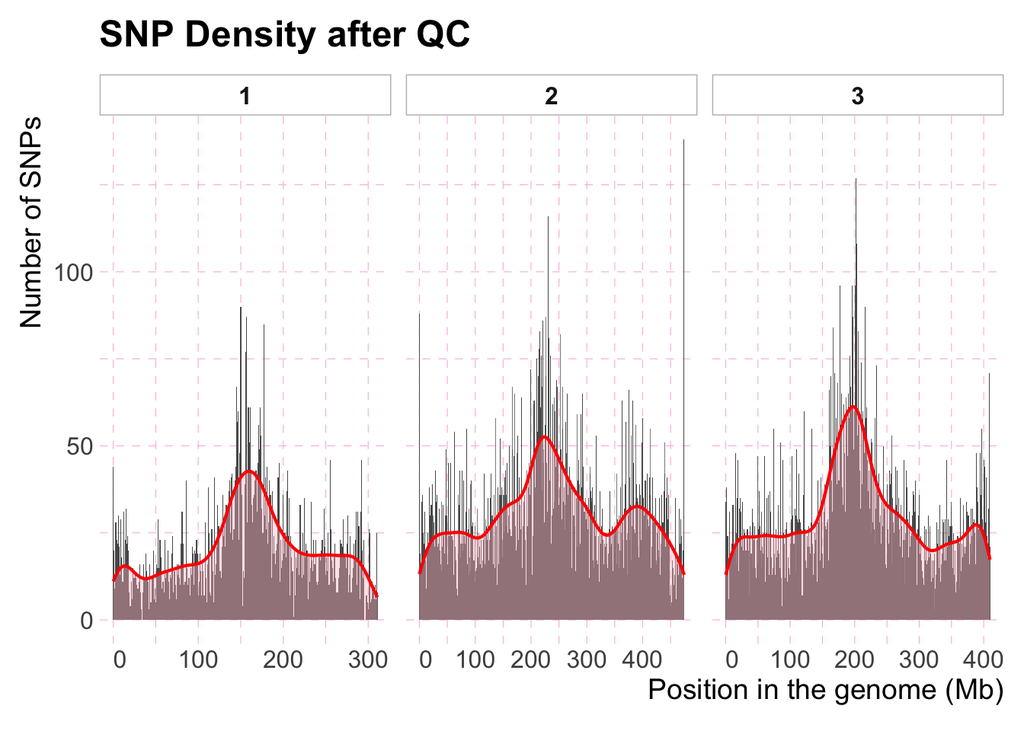

```r
#   ____________________________________________________________________________
#   plot SNP density after QC                                               ####
snp_den_qc |>
  dplyr::rename(
    Chromosome = 1
  ) |>
  mutate(
    Position           = as.numeric(
      Position
    )
  ) |>
  ggplot(
    aes(
      x                = Position
    ),
    label              = sprintf(
      "%0.2f",
      round(
        a,
        digits         = 0
      )
    )
  ) +
  geom_histogram(
    aes(
      y                = after_stat(
        count
      )
    ),
    binwidth           = 1e6
  ) +
  facet_wrap(
    vars(
      Chromosome
    ),
    scales             = "free_x"
  ) +
  labs(
    title              = "SNP Density after QC",
    x                  = expression(
      "Position in the genome (Mb)"
    ),
    y                  = expression(
      "Number of SNPs"
    )
  ) +
  scale_x_continuous(
    labels             = function(x) {
      format(
        x / 1e6,
        big.mark       = ",",
        scientific     = FALSE
      )
    }
  ) +
  geom_density(
  aes(
    y = 1e6 * after_stat(count)
  ),
  color = "red",
  linewidth = .75,
  alpha = .4,
  fill = "pink"
  ) +
  hrbrthemes::theme_ipsum(
    base_family        = "",
    axis_text_size     = 12,
    axis_title_size    = 14,
    plot_margin        = margin(
      10, 10, 10, 10
    ),
    grid               = TRUE,
    grid_col           = "#fabbe2"
  ) +
  theme(
    panel.grid.major   = element_line(
      linetype         = "dashed",
      linewidth        = 0.2
    ),
    panel.grid.minor   = element_line(
      linetype         = "dashed",
      linewidth        = 0.2
    ),
    panel.spacing      = unit(0.5, "lines"),
    strip.text         = element_text(
      face             = "bold", hjust = .5
    ),
    strip.background.x = element_rect(
      color            = "gray"
    )
  )
```

```r
#   ____________________________________________________________________________
#   save the density plot                                            ####
ggsave(
  here(
    "output", "segregation","figures", "snp_density_after_mapping.pdf"
  ),
  width  = 10,
  height = 6,
  units  = "in"
)
```

SNPs per chromosome

```r
# we can use dplyr "count" to get the number of SNPs for each chromosome
# lets get the data we need
snps_per_chrm <-
  snp_den_qc |>
  count(
    Scaffold) |>
  dplyr::rename(
    Chromosome = 1,
    "SNPs (N) " = 2
  )

# Create the flextable
ft <- flextable::flextable(snps_per_chrm)

# Apply zebra theme
ft <- flextable::theme_zebra(ft)

# Add a caption to the table
ft <- flextable::add_header_lines(ft, "SNPs per chromosome after mapping")
ft
```

| SNPs per chromosome after mapping Chromosome | SNPs per chromosome after mapping SNPs (N) |
| --- | --- |
| 1 | 6,668 |
| 2 | 14,874 |
| 3 | 12,734 |

We can get the mean number of SNPs per chromosome or the entire genome

```r
# we first use dplyr cut_width to get the number of SNPs per 1Mb window
albo_den <-
  snp_den_qc |>
  dplyr::select(
    Scaffold, Position
  ) |>
  group_by(
    Scaffold,
    windows               = cut_width(
      Position,
      width               = 1e6,
      boundary            = 0
    )
  ) |>
  summarise(
    n                     = n(),
    .groups               = "keep"
  ) |>
  group_by(
    Scaffold
  ) |>
  summarise(
    mean                  = mean(n),
    n                     = n(),
    .groups               = "keep"
  ) |>
  dplyr::rename(
    Chromosome            = 1,
    "SNPs per 1Mb window" = 2,
    "Number of windows"   = 3
  )
#
# check the results
snp_table <-
  flextable(
    albo_den
  )
snp_table <- colformat_double(
  x        = snp_table,
  big.mark = ",",
  digits   = 2,
  na_str   = "N/A"
)
snp_table
```

| Chromosome | SNPs per 1Mb window | Number of windows |
| --- | --- | --- |
| 1 | 21.58 | 309 |
| 2 | 31.31 | 475 |
| 3 | 31.06 | 410 |

Merge objects

```r
# we can merge the two data sets we created above into one table
after_qc <-
  snps_per_chrm |>
  left_join(
    albo_den,
    by = "Chromosome"
  )
snp_table2 <- flextable(
  after_qc)
snp_table2 <- colformat_double(
  x        = snp_table2,
  big.mark = ",",
  digits   = 2,
  na_str   = "N/A"
  )
snp_table2
```

| Chromosome | SNPs (N) | SNPs per 1Mb window | Number of windows |
| --- | --- | --- | --- |
| 1 | 6,668 | 21.58 | 309 |
| 2 | 14,874 | 31.31 | 475 |
| 3 | 12,734 | 31.06 | 410 |

## 6. Update crosses files

Now we can update the data from the crosses but use only the SNPs that we have data for. I create a file with only the SNPs that are polymorphic.

```bash
# If you run this chunk you will have to open the file.fam in a text editor and set parents id and sex of each individual. I fix it using bash tools. You can start on the next chunk if you do not want to have to repeat what I did.
# we also check if the reference genome and the reference alleles match.
plink \
--allow-extra-chr \
--file data/aegypti_crosses_poly_nominor_august13_2023 \
--make-bed \
--extract output/segregation/AaegL5_ncbi.txt \
--out output/segregation/file1 \
--silent;

grep "variants" output/segregation/file1.log
```

```
## Performing single-pass .bed write (24553 variants, 100 people).
## 24553 variants loaded from .bim file.
## --extract: 18002 variants remaining.
## 18002 variants and 100 people pass filters and QC.
```

We have data for 18002 SNPs, now we can lift their position to the current genome

Check the bim file

```bash
head output/segregation/file1.bim
```

```
## SC1.1    AX-93259337 0   160545  A   C
## SC1.1    AX-93213914 0   344873  T   A
## SC1.1    AX-93213918 0   401303  C   A
## SC1.1    AX-93213920 0   403380  G   A
## SC1.1    AX-93213922 0   413542  T   G
## SC1.1    AX-93213924 0   530962  G   A
## SC1.1    AX-93213930 0   699818  G   A
## SC1.1    AX-93213933 0   840129  C   T
## SC1.1    AX-93213935 0   922251  T   G
## SC1.1    AX-93213937 0   923397  C   T
```

Import the bim file from the crosses

```r
# import the file
file1 <- import_bim(
  here(
    "output", "segregation", "file1.bim"
  )
)

# Convert to data table
setDT(file1)

# Rename columns
setnames(file1, "SNP", "SNP_id")
setnames(file1, "Scaffold", "Scaffold_chip")
setnames(file1, "Position", "Position_chip")

head(file1)
```

```
##    Scaffold_chip      SNP_id Cm Position_chip Allele1 Allele2
## 1:         SC1.1 AX-93259337  0        160545       A       C
## 2:         SC1.1 AX-93213914  0        344873       T       A
## 3:         SC1.1 AX-93213918  0        401303       C       A
## 4:         SC1.1 AX-93213920  0        403380       G       A
## 5:         SC1.1 AX-93213922  0        413542       T       G
## 6:         SC1.1 AX-93213924  0        530962       G       A
```

Merge the data

```r
# Merge the data tables based on the "SNP_id" column
merged_data3 <- merge(snps_pos, file1, by = "SNP_id")
head(merged_data3)
```

```
##         SNP_id Chromosome  Position Scaffold_chip Cm Position_chip Allele1
## 1: AX-93213914          1 242705901         SC1.1  0        344873       T
## 2: AX-93213918          1 242643229         SC1.1  0        401303       C
## 3: AX-93213920          1 242641057         SC1.1  0        403380       G
## 4: AX-93213922          1 242630885         SC1.1  0        413542       T
## 5: AX-93213924          2 184465554         SC1.1  0        530962       G
## 6: AX-93213930          3 106521244         SC1.1  0        699818       G
##    Allele2
## 1:       A
## 2:       A
## 3:       A
## 4:       G
## 5:       A
## 6:       A
```

Select the columns we need

```r
# Select the columns we need for bim file
merged_data4 <-
  merged_data3 |>
  dplyr::select(
    Chromosome, SNP_id, Cm, Position, Allele1, Allele2
  )
# check it
head(merged_data4)
```

```
##    Chromosome      SNP_id Cm  Position Allele1 Allele2
## 1:          1 AX-93213914  0 242705901       T       A
## 2:          1 AX-93213918  0 242643229       C       A
## 3:          1 AX-93213920  0 242641057       G       A
## 4:          1 AX-93213922  0 242630885       T       G
## 5:          2 AX-93213924  0 184465554       G       A
## 6:          3 AX-93213930  0 106521244       G       A
```

```r
# Merge the data and keep the order based on SNP_id in file8
merged_data_ordered2 <- merge(file1, merged_data4, by = "SNP_id", sort = FALSE)

# Select the columns we need for bim file
merged_data_ordered2 <-
  merged_data_ordered2 |>
  dplyr::select(
    Chromosome, SNP_id, Cm.x, Position, Allele1.x, Allele2.x
  )

# Show the first few rows of the merged data
head(merged_data_ordered2)
```

```
##    Chromosome      SNP_id Cm.x  Position Allele1.x Allele2.x
## 1:          1 AX-93259337    0 242911943         A         C
## 2:          1 AX-93213914    0 242705901         T         A
## 3:          1 AX-93213918    0 242643229         C         A
## 4:          1 AX-93213920    0 242641057         G         A
## 5:          1 AX-93213922    0 242630885         T         G
## 6:          2 AX-93213924    0 184465554         G         A
```

Check if the order of the SNP match the file1.bim

```bash
head output/segregation/file1.bim
```

```
## SC1.1    AX-93259337 0   160545  A   C
## SC1.1    AX-93213914 0   344873  T   A
## SC1.1    AX-93213918 0   401303  C   A
## SC1.1    AX-93213920 0   403380  G   A
## SC1.1    AX-93213922 0   413542  T   G
## SC1.1    AX-93213924 0   530962  G   A
## SC1.1    AX-93213930 0   699818  G   A
## SC1.1    AX-93213933 0   840129  C   T
## SC1.1    AX-93213935 0   922251  T   G
## SC1.1    AX-93213937 0   923397  C   T
```

Save the new .bim file

```r
write.table(
  merged_data_ordered2,
  file      = here(
    "output", "segregation", "file1B.bim"
  ),
  sep       = "\t",
  row.names = FALSE,
  col.names = FALSE,
  quote     = FALSE
)
```

Rename the .bim files

```bash
# change the name of the first .bim file, for example, append _backup.bim, and then replace the original file
mv output/segregation/file1.bim output/segregation/file1_backup.bim;
# than change the new bim we create to the original name (do it only once, otherwise it will mess up)
mv output/segregation/file1B.bim output/segregation/file1.bim
```

Create a new bed file with Plink to see if it works. For example, to see if the variants are in the right order

```bash
plink \
--keep-allele-order \
--bfile output/segregation/file1 \
--make-bed \
--allow-extra-chr \
--out output/segregation/file2;
```

[output not shown]

Check the new bim file

```bash
head output/segregation/file2.bim
```

```
## 1    AX-93255723 0   61265   G   A
## 1    AX-93255722 0   104497  A   T
## 1    AX-93255714 0   172093  C   T
## 1    AX-93255713 0   179464  G   A
## 1    AX-93255712 0   179618  C   T
## 1    AX-93255711 0   183444  G   A
## 1    AX-93255710 0   186171  A   G
## 1    AX-93255706 0   207375  0   A
## 1    AX-93255704 0   210192  G   A
## 1    AX-93255703 0   212866  A   G
```

Set the reference alleles to match the genome

```bash
plink2 \
--bfile output/segregation/file2 \
--make-bed \
--fa output/probes/genomes/AaegL5_ncbi.fasta.gz \
--ref-from-fa 'force' `# sets REF alleles when it can be done unambiguously, we use force to change the alleles` \
--out output/segregation/file7 \
--silent;
# --keep-allele-order \ if you use Plink 1.9
grep "variants" output/segregation/file7.log; # to get the number of variants from the log file.
```

```
## 18002 variants loaded from output/segregation/file2.bim.
## --ref-from-fa force: 3732 variants changed, 6043 validated.
```

Check the new bim file

```bash
head output/segregation/file7.bim
```

```
## 1    AX-93255723 0   61265   G   A
## 1    AX-93255722 0   104497  A   T
## 1    AX-93255714 0   172093  C   T
## 1    AX-93255713 0   179464  G   A
## 1    AX-93255712 0   179618  C   T
## 1    AX-93255711 0   183444  G   A
## 1    AX-93255710 0   186171  A   G
## 1    AX-93255706 0   207375  .   A
## 1    AX-93255704 0   210192  G   A
## 1    AX-93255703 0   212866  A   G
```

We can see that some SNPs were fixed. For example: 1 AX-93255706 0 207375 0 A Then Plink2 set a . for the 1 AX-93255706 0 207375 . A

We can check the allele from the probes_aegypti_01

```r
alleles <- probes_aegypti_01 |>
  dplyr::select(Name, "Allele A", "Allele B")

head(alleles)
```

```
## # A tibble: 6 × 3
##   Name        `Allele A` `Allele B`
##   <chr>       <chr>      <chr>
## 1 AX-93213911 A          G
## 2 AX-93213912 A          C
## 3 AX-93213914 A          T
## 4 AX-93213915 T          C
## 5 AX-93213916 A          C
## 6 AX-93213917 A          G
```

Write to file

```r
# # Write the unique SNP_ids to a file
write.table(
  alleles,
  file      = here("output", "segregation", "alleles.txt"),
  sep       = "\t",
  row.names = FALSE,
  col.names = FALSE,
  quote     = FALSE
)
```

Check it

```bash
head output/segregation/alleles.txt
```

```
## AX-93213911  A   G
## AX-93213912  A   C
## AX-93213914  A   T
## AX-93213915  T   C
## AX-93213916  A   C
## AX-93213917  A   G
## AX-93213918  A   C
## AX-93213919  A   G
## AX-93213920  A   G
## AX-93213921  A   G
```

Import .bim

```r
# import the file
file7 <- import_bim(
  here(
    "output", "segregation", "file7.bim"
  )
)

colnames(file7) <- c("Chromosome", "SNP_ID", "Cm", "Position", "Allele1", "Allele2")

head(file7)
```

```
## # A tibble: 6 × 6
##   Chromosome SNP_ID         Cm Position Allele1 Allele2
##   <chr>      <chr>       <int>    <dbl> <chr>   <chr>
## 1 1          AX-93255723     0    61265 G       A
## 2 1          AX-93255722     0   104497 A       T
## 3 1          AX-93255714     0   172093 C       T
## 4 1          AX-93255713     0   179464 G       A
## 5 1          AX-93255712     0   179618 C       T
## 6 1          AX-93255711     0   183444 G       A
```

Import alleles

```r
# Read the alleles file
alleles_data <- read.table("output/segregation/alleles.txt", header = FALSE)
colnames(alleles_data) <- c("SNP_ID", "Allele_A", "Allele_B")
head(alleles_data)
```

```
##        SNP_ID Allele_A Allele_B
## 1 AX-93213911        A        G
## 2 AX-93213912        A        C
## 3 AX-93213914        A        T
## 4 AX-93213915        T        C
## 5 AX-93213916        A        C
## 6 AX-93213917        A        G
```

Merge

```r
# # Merge the data based on SNP_ID
# merged_data5 <- merge(file7, alleles_data, by = "SNP_ID")
# Merge the data based on SNP_ID, preserving the order in file7
merged_data5 <- merge(file7, alleles_data, by = "SNP_ID", all.x = TRUE, sort = FALSE)

head(merged_data5)
```

```
##        SNP_ID Chromosome Cm Position Allele1 Allele2 Allele_A Allele_B
## 1 AX-93255723          1  0    61265       G       A        A        G
## 2 AX-93255722          1  0   104497       A       T        A        T
## 3 AX-93255714          1  0   172093       C       T        T        C
## 4 AX-93255713          1  0   179464       G       A        A        G
## 5 AX-93255712          1  0   179618       C       T        T        C
## 6 AX-93255711          1  0   183444       G       A        A        G
```

Check the SNPs for which the alternative allele is missing

```r
head(merged_data5 |>
       filter(Allele1 == "."))
```

```
##        SNP_ID Chromosome Cm Position Allele1 Allele2 Allele_A Allele_B
## 1 AX-93255706          1  0   207375       .       A        A        G
## 2 AX-93214756          1  0  8062821       .       C        T        C
## 3 AX-93222551          1  0 11682709       .       T        T        C
## 4 AX-93222558          1  0 11776195       .       A        A        G
## 5 AX-93263645          1  0 23769897       .       A        A        T
## 6 AX-93222102          1  0 25336432       .       T        T        G
```

Plink2 set the allele2 as the reference allele

```r
# Loop through the rows and correct the alleles
for (i in 1:nrow(merged_data5)) {
  if (merged_data5$Allele1[i] == ".") {
    if (merged_data5$Allele2[i] == merged_data5$Allele_B[i]) {
      # Replace Allele1 with Allele_A if Allele2 matches Allele_B
      merged_data5$Allele1[i] <- merged_data5$Allele_A[i]
    } else if (merged_data5$Allele2[i] == merged_data5$Allele_A[i]) {
      # Replace Allele1 with Allele_B if Allele2 matches Allele_A
      merged_data5$Allele1[i] <- merged_data5$Allele_B[i]
    } else {
      # Print a warning if neither allele matches
      warning(paste("No match found for SNP_ID", merged_data5$SNP_ID[i]))
    }
  }
}

# Create the corrected .bim file
corrected_bim <- merged_data5[, c("Chromosome", "SNP_ID", "Cm", "Position", "Allele1", "Allele2")]
```

Now check if we fixed the problem

```r
# Check one SNP
corrected_bim |>
       filter(SNP_ID == "AX-93214499")
```

```
##   Chromosome      SNP_ID Cm  Position Allele1 Allele2
## 1          3 AX-93214499  0 212743622       T       C
```

Save the new .bim file

```r
write.table(
  corrected_bim,
  file      = here(
    "output", "segregation", "file7b.bim"
  ),
  sep       = "\t",
  row.names = FALSE,
  col.names = FALSE,
  quote     = FALSE
)
```

Rename the .bim files

```bash
# change the name of the first .bim file, for example, append _backup.bim, and then replace the original file
mv output/segregation/file7.bim output/segregation/file7_backup.bim;
# than change the new bim we create to the original name (do it only once, otherwise it will mess up)
mv output/segregation/file7b.bim output/segregation/file7.bim
```

Now we can check if the alleles are correct Import .bim

```r
# import the file
file7 <- import_bim(
  here(
    "output", "segregation", "file7.bim"
  )
)

colnames(file7) <- c("Chromosome", "SNP_ID", "Cm", "Position", "Allele1", "Allele2")

head(file7)
```

```
## # A tibble: 6 × 6
##   Chromosome SNP_ID         Cm Position Allele1 Allele2
##   <chr>      <chr>       <int>    <dbl> <chr>   <chr>
## 1 1          AX-93255723     0    61265 G       A
## 2 1          AX-93255722     0   104497 A       T
## 3 1          AX-93255714     0   172093 C       T
## 4 1          AX-93255713     0   179464 G       A
## 5 1          AX-93255712     0   179618 C       T
## 6 1          AX-93255711     0   183444 G       A
```

Check the SNPs for which the alternative allele is missing

```r
head(file7 |>
       filter(Allele1 == "."))
```

[output not shown]

We can repeat the set reference with Plink2 Set the reference alleles to match the genome

```bash
plink2 \
--bfile output/segregation/file7 \
--make-bed \
--fa output/probes/genomes/AaegL5_ncbi.fasta.gz \
--ref-from-fa 'force' `# sets REF alleles when it can be done unambiguously, we use force to change the alleles` \
--out output/segregation/file8 \
--silent;

grep "variants" output/segregation/file8.log
```

```
## 18002 variants loaded from output/segregation/file7.bim.
## --ref-from-fa force: 0 variants changed, 9775 validated.
```

Check the .bim file

```bash
head output/segregation/file8.bim
```

```
## 1    AX-93255723 0   61265   G   A
## 1    AX-93255722 0   104497  A   T
## 1    AX-93255714 0   172093  C   T
## 1    AX-93255713 0   179464  G   A
## 1    AX-93255712 0   179618  C   T
## 1    AX-93255711 0   183444  G   A
## 1    AX-93255710 0   186171  A   G
## 1    AX-93255706 0   207375  .   A
## 1    AX-93255704 0   210192  G   A
## 1    AX-93255703 0   212866  A   G
```